# Different languages, similar encoding efficiency

## Generalized Additive Models for Location, Scale and Shape (GAMLSS)

We will use a Gaussian distribution (with fixed or modelled variance).

### SR

#### Fixed or modelled *σ* (variance)

##### Fixed *σ*

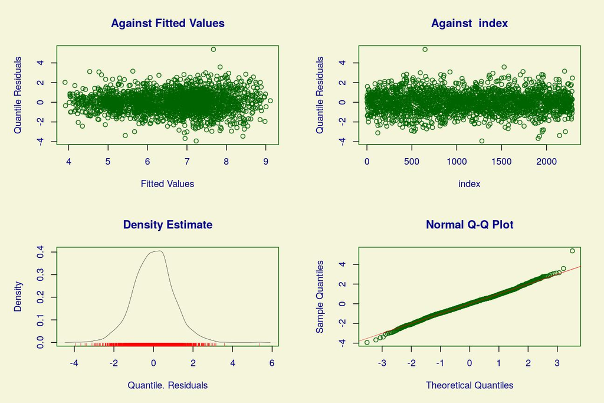

```
          Summary of the Quantile Residuals
                           mean   =  -7.131581e-05
                       variance   =  1.000437
               coef. of skewness  =  0.04303609
               coef. of kurtosis  =  3.710291
Filliben correlation coefficient  =  0.9979187
```

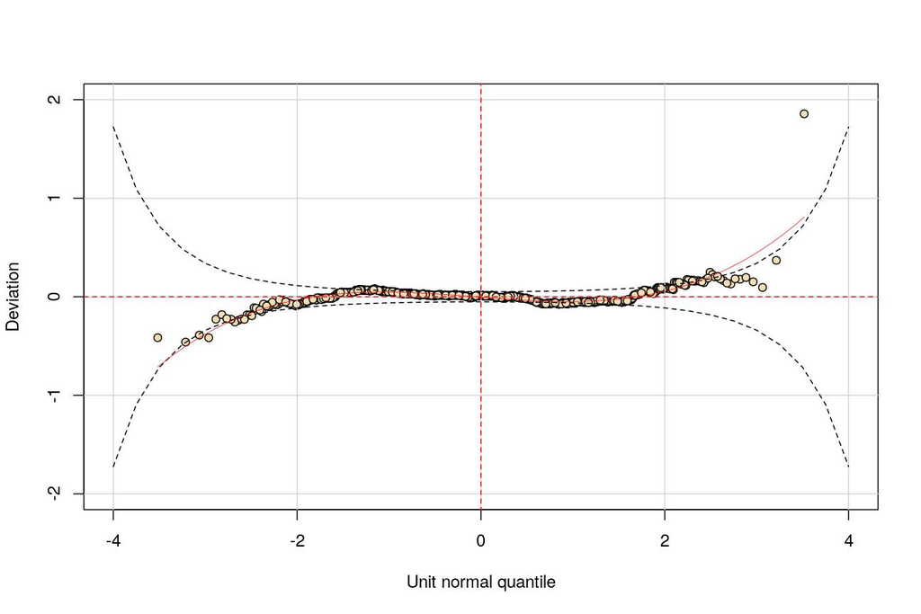

```
Deviance= 1177.818
```

```
AIC= 1576.98
```

##### Modelled *σ*

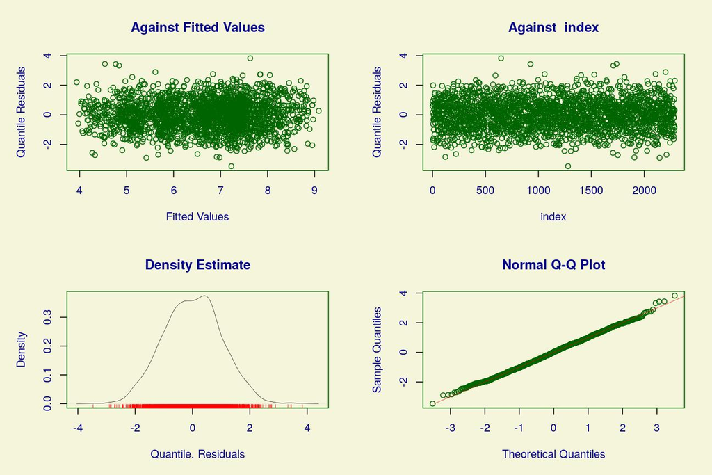

```
          Summary of the Quantile Residuals
                           mean   =  0.002001851
                       variance   =  1.000433
               coef. of skewness  =  0.03014483
               coef. of kurtosis  =  2.864355
Filliben correlation coefficient  =  0.9994151
```

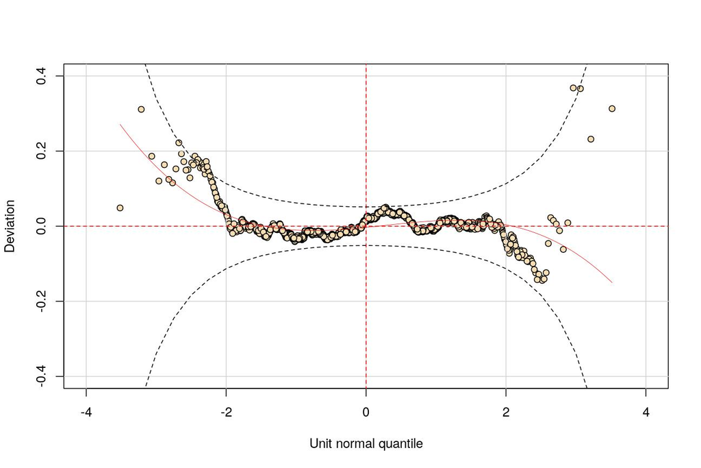

```
Deviance= 815.9172
```

```
AIC= 1405.705
```

The distribution of the residuals is less heteroscedastic than before and the fit to the data better. The full summary of the model is:

```
Family:  c("NO", "Normal")

Call:  gamlss(formula = SR ~ 1 + Sex + random(Text) + random(Language) +      random(Family) + random(Speaker), sigma.formula = ~1 +      Sex + random(Text) + random(Language) + random(Family) +
    random(Speaker), family = NO(mu.link = "identity"),      data = d, control = gamlss.control(n.cyc = 800,          trace = FALSE), i.control = glim.control(bf.cyc = 800))

Fitting method: RS()

------------------------------------------------------------------
Mu link function:  identity
Mu Coefficients:
             Estimate Std. Error t value Pr(>|t|)
(Intercept)  6.629552   0.005816 1139.83   <2e-16 ***
Sex1        -0.168157   0.005816  -28.91   <2e-16 ***
---
Signif. codes:  0 '***' 0.001 '**' 0.01 '*' 0.05 '.' 0.1 ' ' 1

------------------------------------------------------------------
Sigma link function:  log
Sigma Coefficients:
            Estimate Std. Error t value Pr(>|t|)
(Intercept) -1.23693    0.01478 -83.673  < 2e-16 ***
Sex1        -0.05788    0.01478  -3.915 9.34e-05 ***
---
Signif. codes:  0 '***' 0.001 '**' 0.01 '*' 0.05 '.' 0.1 ' ' 1

------------------------------------------------------------------
NOTE: Additive smoothing terms exist in the formulas:
 i) Std. Error for smoothers are for the linear effect only.
ii) Std. Error for the linear terms maybe are not accurate.
------------------------------------------------------------------
No. of observations in the fit:  2288
Degrees of Freedom for the fit:  294.8937
      Residual Deg. of Freedom:  1993.106
                      at cycle:  53

Global Deviance:     815.9172
            AIC:     1405.705
            SBC:     3097.048
```

#### Random effects

##### *μ*

**Text**

```
Random effects fit using the gamlss function random()
Degrees of Freedom for the fit : 14.39185
Random effect parameter sigma_b: 0.109103
Smoothing parameter lambda     : 84.5402
```

**Language**

```
Random effects fit using the gamlss function random()
Degrees of Freedom for the fit : 16.98344
Random effect parameter sigma_b: 0.870621
Smoothing parameter lambda     : 1.32916
```

**Family**

```
Random effects fit using the gamlss function random()
Degrees of Freedom for the fit : 0.01237646
Random effect parameter sigma_b: 1.91981e-05
Smoothing parameter lambda     : 2713240000
```

**Speaker**

```
Random effects fit using the gamlss function random()
Degrees of Freedom for the fit : 165.4211
Random effect parameter sigma_b: 0.569042
Smoothing parameter lambda     : 3.32891
```

##### *σ*

**Text**

```
Random effects fit using the gamlss function random()
Degrees of Freedom for the fit : 0.00152528
Random effect parameter sigma_b: 0.000518285
Smoothing parameter lambda     : 3475370
```

**Language**

```
Random effects fit using the gamlss function random()
Degrees of Freedom for the fit : 14.62296
Random effect parameter sigma_b: 0.153319
Smoothing parameter lambda     : 39.9698
```

**Family**

```
Random effects fit using the gamlss function random()
Degrees of Freedom for the fit : 0.001713103
Random effect parameter sigma_b: 0.000184844
Smoothing parameter lambda     : 27323100
```

**Speaker**

```
Random effects fit using the gamlss function random()
Degrees of Freedom for the fit : 79.45882
Random effect parameter sigma_b: 0.181484
Smoothing parameter lambda     : 29.3639
```

### IR

#### Fixed or modelled *σ* (variance)

##### Fixed *σ*

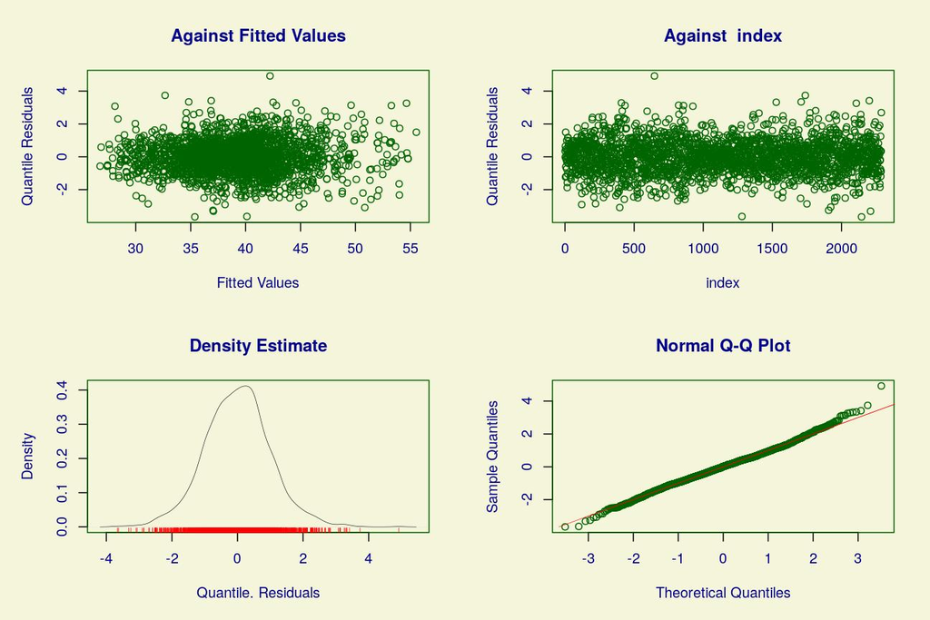

```
          Summary of the Quantile Residuals
                           mean   =  8.557955e-05
                       variance   =  1.000437
               coef. of skewness  =  0.09721211
               coef. of kurtosis  =  3.684191
Filliben correlation coefficient  =  0.9978017
```

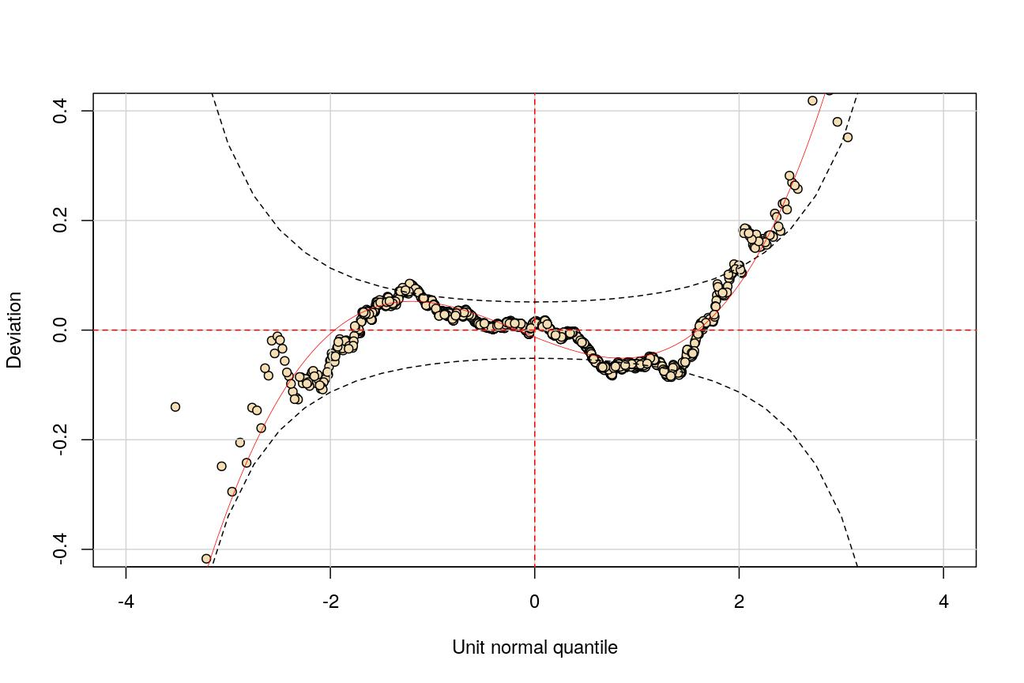

```
Deviance= 9322.636
```

```
AIC= 9721.861
```

##### Modelled *σ*

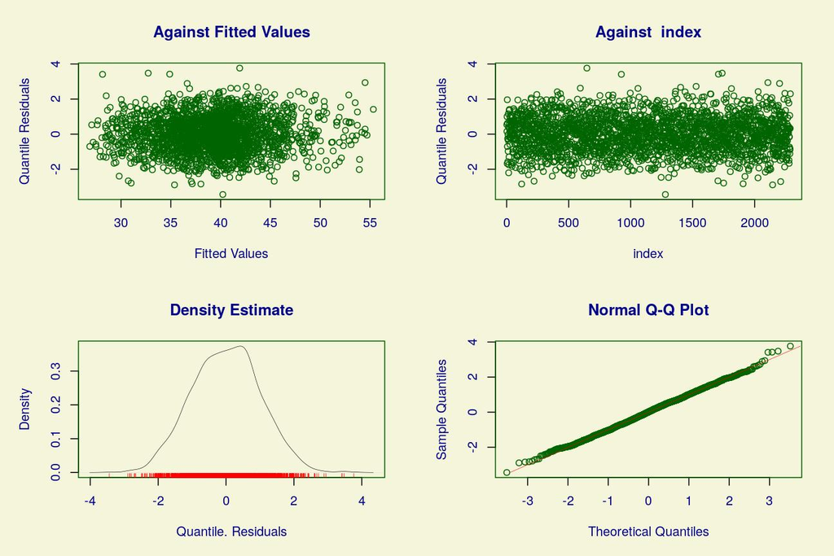

```
          Summary of the Quantile Residuals
                           mean   =  0.002104815
                       variance   =  1.000442
               coef. of skewness  =  0.03139581
               coef. of kurtosis  =  2.864031
Filliben correlation coefficient  =  0.9993924
```

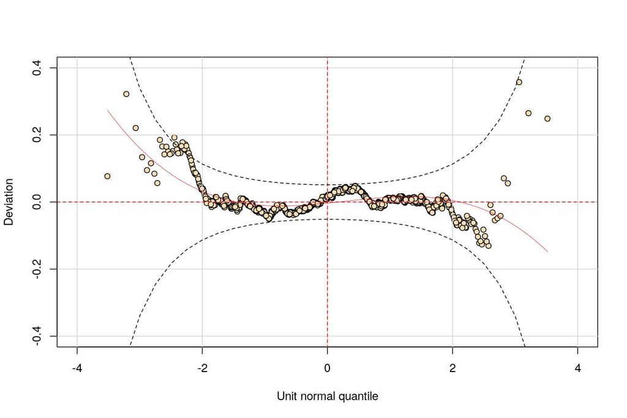

```
Deviance= 8961.553
```

```
AIC= 9554.321
```

Again, this is a better fit to the data. The full summary of the model is:

```
Family:  c("NO", "Normal")

Call:  gamlss(formula = IR ~ 1 + Sex + random(Text) + random(Language) +      random(Family) + random(Speaker), sigma.formula = ~1 +      Sex + random(Text) + random(Language) + random(Family) +
    random(Speaker), family = NO(mu.link = "identity"),      data = d, control = gamlss.control(n.cyc = 800,          trace = FALSE), i.control = glim.control(bf.cyc = 800))

Fitting method: RS()

------------------------------------------------------------------
Mu link function:  identity
Mu Coefficients:
            Estimate Std. Error t value Pr(>|t|)
(Intercept) 39.14451    0.03463 1130.31   <2e-16 ***
Sex1        -1.01064    0.03463  -29.18   <2e-16 ***
---
Signif. codes:  0 '***' 0.001 '**' 0.01 '*' 0.05 '.' 0.1 ' ' 1

------------------------------------------------------------------
Sigma link function:  log
Sigma Coefficients:
            Estimate Std. Error t value Pr(>|t|)
(Intercept)  0.54554    0.01478  36.903  < 2e-16 ***
Sex1        -0.05935    0.01478  -4.015 6.17e-05 ***
---
Signif. codes:  0 '***' 0.001 '**' 0.01 '*' 0.05 '.' 0.1 ' ' 1

------------------------------------------------------------------
NOTE: Additive smoothing terms exist in the formulas:
 i) Std. Error for smoothers are for the linear effect only.
ii) Std. Error for the linear terms maybe are not accurate.
------------------------------------------------------------------
No. of observations in the fit:  2288
Degrees of Freedom for the fit:  296.3836
      Residual Deg. of Freedom:  1991.616
                      at cycle:  6

Global Deviance:     8961.553
            AIC:     9554.321
            SBC:     11254.21
```

#### Random effects

##### *μ*

**Text**

```
Random effects fit using the gamlss function random()
Degrees of Freedom for the fit : 14.41202
Random effect parameter sigma_b: 0.660353
Smoothing parameter lambda     : 2.30777
```

**Language**

```
Random effects fit using the gamlss function random()
Degrees of Freedom for the fit : 16.95235
Random effect parameter sigma_b: 3.10086
Smoothing parameter lambda     : 0.104779
```

**Family**

```
Random effects fit using the gamlss function random()
Degrees of Freedom for the fit : 0.01908253
Random effect parameter sigma_b: 0.000233421
Smoothing parameter lambda     : 18354000
```

**Speaker**

```
Random effects fit using the gamlss function random()
Degrees of Freedom for the fit : 165.2917
Random effect parameter sigma_b: 3.39374
Smoothing parameter lambda     : 0.0935855
```

##### *σ*

**Text**

```
Random effects fit using the gamlss function random()
Degrees of Freedom for the fit : 0.0004688834
Random effect parameter sigma_b: 0.000282878
Smoothing parameter lambda     : 11664800
```

**Language**

```
Random effects fit using the gamlss function random()
Degrees of Freedom for the fit : 14.73159
Random effect parameter sigma_b: 0.157607
Smoothing parameter lambda     : 37.8208
```

**Family**

```
Random effects fit using the gamlss function random()
Degrees of Freedom for the fit : 0.001453389
Random effect parameter sigma_b: 0.00011236
Smoothing parameter lambda     : 73935500
```

**Speaker**

```
Random effects fit using the gamlss function random()
Degrees of Freedom for the fit : 80.97495
Random effect parameter sigma_b: 0.184921
Smoothing parameter lambda     : 28.2979
```

## Modelling the relationship between SR and ID

Let’s model *SR* with *ID* as an additional predictor (fixed effect) interacting with *Sex*. *N.B.* In this case, we must drop *Language* as a random effect, since each language has, by definition, only one value of *ID.*

```
Family:  c("NO", "Normal")

Call:  gamlss(formula = SR ~ 1 + ID * Sex + random(Text) +      random(Speaker) + random(Family), sigma.formula = ~1 +      ID + Sex + random(Text) + random(Speaker) + random(Family),
    family = NO(mu.link = "identity"), data = d, control = gamlss.control(n.cyc = 800,          trace = FALSE), i.control = glim.control(bf.cyc = 800))

Fitting method: RS()

------------------------------------------------------------------
Mu link function:  identity
Mu Coefficients:
             Estimate Std. Error  t value Pr(>|t|)
(Intercept) 11.970094   0.037525  318.987  < 2e-16 ***
ID          -0.888703   0.005992 -148.324  < 2e-16 ***
Sex1        -0.062504   0.037524   -1.666  0.09593 .
ID:Sex1     -0.017079   0.005991   -2.851  0.00441 **
---
Signif. codes:  0 '***' 0.001 '**' 0.01 '*' 0.05 '.' 0.1 ' ' 1

------------------------------------------------------------------
Sigma link function:  log
Sigma Coefficients:
            Estimate Std. Error t value Pr(>|t|)
(Intercept) -0.73603    0.10289  -7.153 1.18e-12 ***
ID          -0.08460    0.01694  -4.993 6.45e-07 ***
Sex1        -0.05723    0.01478  -3.871 0.000112 ***
---
Signif. codes:  0 '***' 0.001 '**' 0.01 '*' 0.05 '.' 0.1 ' ' 1

------------------------------------------------------------------
NOTE: Additive smoothing terms exist in the formulas:
 i) Std. Error for smoothers are for the linear effect only.
ii) Std. Error for the linear terms maybe are not accurate.
------------------------------------------------------------------
No. of observations in the fit:  2288
Degrees of Freedom for the fit:  293.3745
      Residual Deg. of Freedom:  1994.626
                      at cycle:  8

Global Deviance:     790.2025
            AIC:     1376.951
            SBC:     3059.581
```

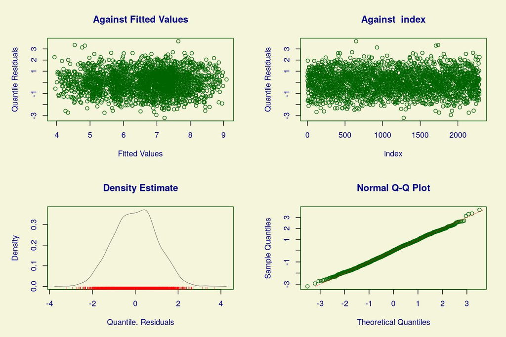

```
          Summary of the Quantile Residuals
                           mean   =  0.001905342
                       variance   =  1.000433
               coef. of skewness  =  0.01947475
               coef. of kurtosis  =  2.77394
Filliben correlation coefficient  =  0.9993355
```

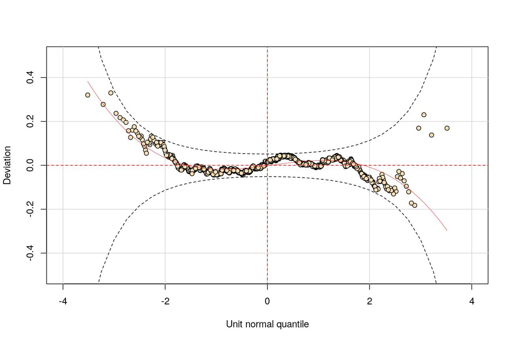

```
Deviance= 790.2025
```

```
AIC= 1376.951
```

Adding *ID* as a predictor improves the fits (as judged by AIC). There is a negative estimate for ID, but significance is difficult to assess with GAMLSS model involving smoothing functions. However, also using a simple `lmer` model we have a significant effect of *ID*:

```
Linear mixed model fit by REML. t-tests use Satterthwaite's method ['lmerModLmerTest']
Formula: SR ~ 1 + ID * Sex + (1 | Text) + (1 | Speaker) + (1 | Family)
   Data: info.rate.data

REML criterion at convergence: 2121.2

Scaled residuals:
    Min      1Q  Median      3Q     Max
-3.7806 -0.6226  0.0176  0.5808  5.1707

Random effects:
 Groups   Name        Variance Std.Dev.
 Speaker  (Intercept) 0.4618   0.6795
 Text     (Intercept) 0.0172   0.1311
 Family   (Intercept) 0.2443   0.4942
 Residual             0.1063   0.3260
Number of obs: 2288, groups:  Speaker, 170; Text, 15; Family, 9

Fixed effects:
              Estimate Std. Error         df t value Pr(>|t|)
(Intercept)  10.521343   0.637420  42.244565  16.506  < 2e-16 ***
ID           -0.658948   0.101261  54.414768  -6.507 2.52e-08 ***
Sex1         -0.128232   0.367323 155.446204  -0.349    0.727
ID:Sex1      -0.006959   0.060377 155.565771  -0.115    0.908
---
Signif. codes:  0 '***' 0.001 '**' 0.01 '*' 0.05 '.' 0.1 ' ' 1

Correlation of Fixed Effects:
        (Intr) ID     Sex1
ID      -0.959
Sex1     0.002 -0.002
ID:Sex1 -0.002  0.002 -0.990
```

```
Type III Analysis of Variance Table with Satterthwaite's method
       Sum Sq Mean Sq NumDF   DenDF F value    Pr(>F)
ID     4.4998  4.4998     1  54.415 42.3465 2.516e-08 ***
Sex    0.0130  0.0130     1 155.446  0.1219    0.7275
ID:Sex 0.0014  0.0014     1 155.566  0.0133    0.9084
---
Signif. codes:  0 '***' 0.001 '**' 0.01 '*' 0.05 '.' 0.1 ' ' 1
```

### Random effects

#### *μ*

**Text**

```
Random effects fit using the gamlss function random()
Degrees of Freedom for the fit : 14.41708
Random effect parameter sigma_b: 0.11065
Smoothing parameter lambda     : 82.1944
```

**Speaker**

```
Random effects fit using the gamlss function random()
Degrees of Freedom for the fit : 167.4872
Random effect parameter sigma_b: 0.7577
Smoothing parameter lambda     : 1.8794
```

**Family**

```
Random effects fit using the gamlss function random()
Degrees of Freedom for the fit : 0.01763365
Random effect parameter sigma_b: 0.000168856
Smoothing parameter lambda     : 35072900
```

#### *σ*

**Text**

```
Random effects fit using the gamlss function random()
Degrees of Freedom for the fit : 0.03217714
Random effect parameter sigma_b: 0.00241144
Smoothing parameter lambda     : 152754
```

**Speaker**

```
Random effects fit using the gamlss function random()
Degrees of Freedom for the fit : 104.4197
Random effect parameter sigma_b: 0.242522
Smoothing parameter lambda     : 15.8243
```

**Family**

```
Random effects fit using the gamlss function random()
Degrees of Freedom for the fit : 0.000711841
Random effect parameter sigma_b: 0.000279392
Smoothing parameter lambda     : 11379200
```

## Do *Age* and *Sex* matter?

```
Linear mixed model fit by REML. t-tests use Satterthwaite's method ['lmerModLmerTest']
Formula: SR ~ Age * Sex + (1 | Text) + (1 | Language)
   Data: info.rate.data

REML criterion at convergence: 3743.7

Scaled residuals:
    Min      1Q  Median      3Q     Max
-3.4947 -0.6305  0.0105  0.5978  3.6970

Random effects:
 Groups   Name        Variance Std.Dev.
 Text     (Intercept) 0.01299  0.1140
 Language (Intercept) 1.01328  1.0066
 Residual             0.36283  0.6024
Number of obs: 1979, groups:  Text, 15; Language, 14

Fixed effects:
              Estimate Std. Error         df t value Pr(>|t|)
(Intercept)  6.809e+00  2.753e-01  1.417e+01  24.734 4.61e-13 ***
Age         -5.972e-03  1.592e-03  1.951e+03  -3.751 0.000181 ***
Sex1        -1.084e-01  4.608e-02  1.948e+03  -2.351 0.018804 *
Age:Sex1    -1.223e-03  1.440e-03  1.949e+03  -0.849 0.395965
---
Signif. codes:  0 '***' 0.001 '**' 0.01 '*' 0.05 '.' 0.1 ' ' 1

Correlation of Fixed Effects:
         (Intr) Age    Sex1
Age      -0.176
Sex1      0.018 -0.107
Age:Sex1 -0.019  0.115 -0.956
```

```
Linear mixed model fit by REML. t-tests use Satterthwaite's method ['lmerModLmerTest']
Formula: IR ~ Age * Sex + (1 | Text) + (1 | Family/Language)
   Data: info.rate.data

REML criterion at convergence: 10792.3

Scaled residuals:
    Min      1Q  Median      3Q     Max
-3.2256 -0.6274  0.0068  0.5901  4.6601

Random effects:
 Groups          Name        Variance Std.Dev.
 Text            (Intercept)  0.4338  0.6586
 Language:Family (Intercept)  8.4982  2.9152
 Family          (Intercept)  2.1402  1.4629
 Residual                    12.9843  3.6034
Number of obs: 1979, groups:  Text, 15; Language:Family, 14; Family, 9

Fixed effects:
              Estimate Std. Error         df t value Pr(>|t|)
(Intercept)  3.996e+01  1.009e+00  1.049e+01  39.596 9.13e-13 ***
Age         -3.985e-02  9.517e-03  1.954e+03  -4.187 2.95e-05 ***
Sex1        -6.705e-01  2.756e-01  1.950e+03  -2.433   0.0151 *
Age:Sex1    -7.286e-03  8.615e-03  1.950e+03  -0.846   0.3978
---
Signif. codes:  0 '***' 0.001 '**' 0.01 '*' 0.05 '.' 0.1 ' ' 1

Correlation of Fixed Effects:
         (Intr) Age    Sex1
Age      -0.285
Sex1      0.028 -0.106
Age:Sex1 -0.030  0.114 -0.956
```

So, it seems *Age* and *Sex* are both worth including in our models (even if we have to discard quite a bit of data because of missing *Age* info) (in fact, the effect of *Age* seems more significant than that of *Sex*).

In the following, we investigate if *Age* does matter when using GAMLSS modelling.

### GAMLSS with Age

Bescause there is missing data from *Age*, and because the GAMLSS models require no missing data, we will fit the models with *Age* (and its interaction with *Sex*) on the subset of the data that contains only those speakers with *Age* info. To make comparability possible, we also fit the same models but without *Age* on the exact same subset of the data.

#### SR

##### Fixed or modelled *σ* (variance)

###### Fixed *σ*

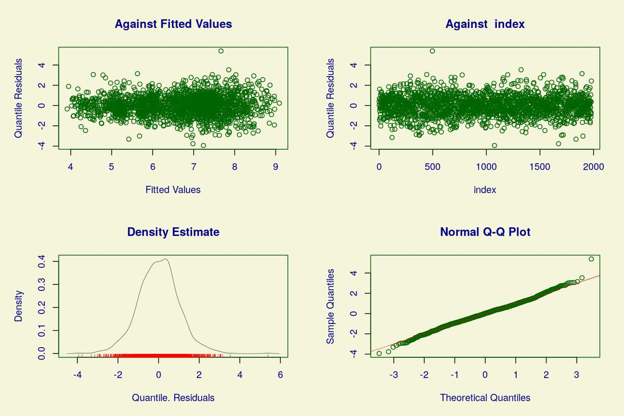

```
          Summary of the Quantile Residuals
                           mean   =  -8.252732e-05
                       variance   =  1.000506
               coef. of skewness  =  0.04585
               coef. of kurtosis  =  3.821224
Filliben correlation coefficient  =  0.9973638
```

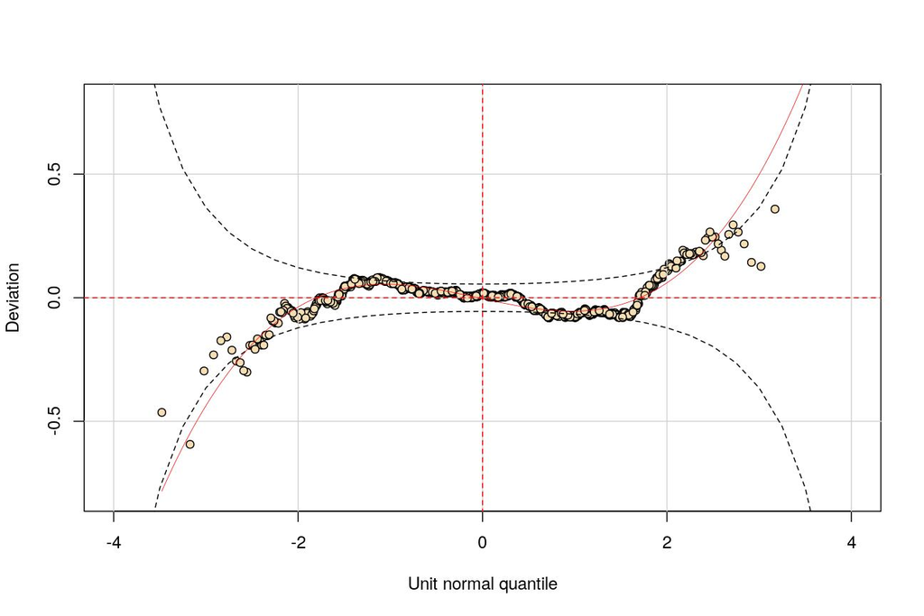

The model including *Age* * *Sex* is:

```
Family:  c("NO", "Normal")

Call:  gamlss(formula = SR ~ 1 + Sex * Age + random(Text) +      random(Language) + random(Family) + random(Speaker),      family = NO(mu.link = "identity"), data = info.rate.data.for.age,      control = gamlss.control(n.cyc = 800, trace = FALSE),
    i.control = glim.control(bf.cyc = 800))

Fitting method: RS()

------------------------------------------------------------------
Mu link function:  identity
Mu Coefficients:
              Estimate Std. Error t value Pr(>|t|)
(Intercept)  6.7419779  0.0234704 287.254  < 2e-16 ***
Sex1        -0.0916878  0.0234704  -3.907 9.71e-05 ***
Age         -0.0024831  0.0007319  -3.393 0.000707 ***
Sex1:Age    -0.0017244  0.0007319  -2.356 0.018566 *
---
Signif. codes:  0 '***' 0.001 '**' 0.01 '*' 0.05 '.' 0.1 ' ' 1

------------------------------------------------------------------
Sigma link function:  log
Sigma Coefficients:
            Estimate Std. Error t value Pr(>|t|)
(Intercept)  -1.1605     0.0159  -73.01   <2e-16 ***
---
Signif. codes:  0 '***' 0.001 '**' 0.01 '*' 0.05 '.' 0.1 ' ' 1

------------------------------------------------------------------
NOTE: Additive smoothing terms exist in the formulas:
 i) Std. Error for smoothers are for the linear effect only.
ii) Std. Error for the linear terms maybe are not accurate.
------------------------------------------------------------------
No. of observations in the fit:  1979
Degrees of Freedom for the fit:  161.6924
      Residual Deg. of Freedom:  1817.308
                      at cycle:  35

Global Deviance:     1022.798
            AIC:     1346.183
            SBC:     2250.099
```

The compared models are:

| Model | Deviance | AIC |
| --- | --- | --- |
| *Age* * *Sex* | 1022.8 | 1346.2 |
| *Age* + *Sex* | 1022.8 | 1344.2 |
| *Sex* | 1022.8 | 1342.2 |

So, even if *Age* has a significant (negative) effect and interaction with *Sex* (positive for males), adding it does not seem to be warranted here…

###### Modelled *σ*

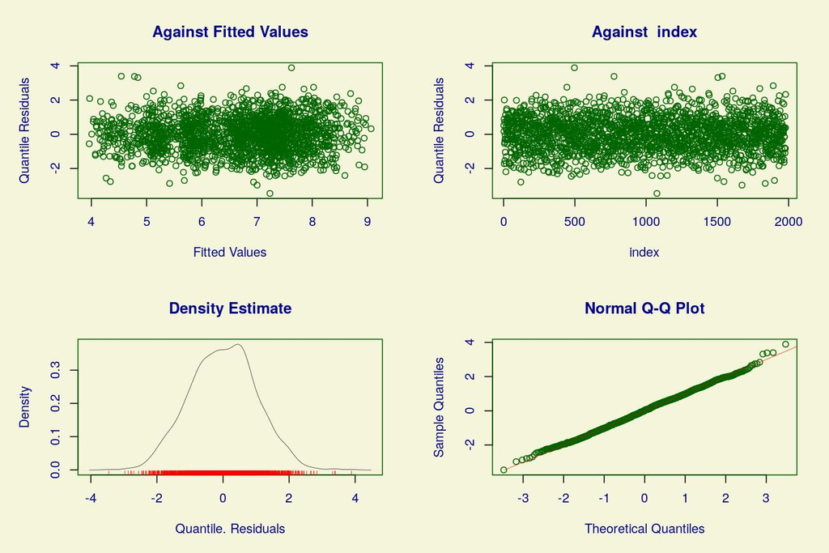

```
          Summary of the Quantile Residuals
                           mean   =  0.002353284
                       variance   =  1.000499
               coef. of skewness  =  0.02299299
               coef. of kurtosis  =  2.90592
Filliben correlation coefficient  =  0.9993823
```

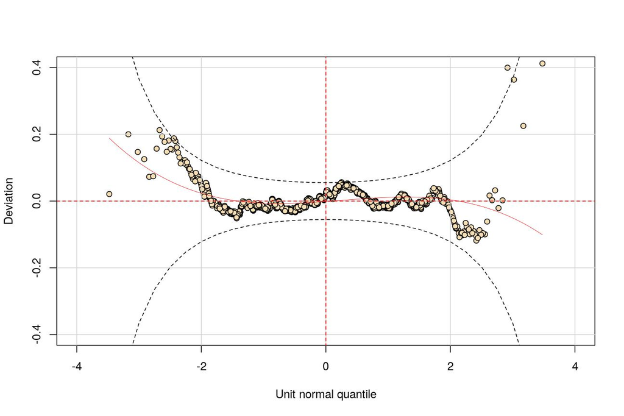

The model including *Age* * *Sex* is:

```
Family:  c("NO", "Normal")

Call:  gamlss(formula = SR ~ 1 + Sex * Age + random(Text) +      random(Language) + random(Family) + random(Speaker),      sigma.formula = ~1 + Sex * Age + random(Text) +          random(Language) + random(Family) + random(Speaker),
    family = NO(mu.link = "identity"), data = info.rate.data.for.age,      control = gamlss.control(n.cyc = 800, trace = FALSE),      i.control = glim.control(bf.cyc = 800))

Fitting method: RS()

------------------------------------------------------------------
Mu link function:  identity
Mu Coefficients:
              Estimate Std. Error t value Pr(>|t|)
(Intercept)  6.5465239  0.0203601 321.536  < 2e-16 ***
Sex1        -0.0442321  0.0203601  -2.172     0.03 *
Age          0.0038165  0.0006483   5.887 4.71e-09 ***
Sex1:Age    -0.0030913  0.0006483  -4.768 2.01e-06 ***
---
Signif. codes:  0 '***' 0.001 '**' 0.01 '*' 0.05 '.' 0.1 ' ' 1

------------------------------------------------------------------
Sigma link function:  log
Sigma Coefficients:
             Estimate Std. Error t value Pr(>|t|)
(Intercept) -1.330351   0.053970 -24.650   <2e-16 ***
Sex1         0.019846   0.053970   0.368   0.7131
Age          0.003029   0.001685   1.798   0.0724 .
Sex1:Age    -0.002561   0.001685  -1.520   0.1286
---
Signif. codes:  0 '***' 0.001 '**' 0.01 '*' 0.05 '.' 0.1 ' ' 1

------------------------------------------------------------------
NOTE: Additive smoothing terms exist in the formulas:
 i) Std. Error for smoothers are for the linear effect only.
ii) Std. Error for the linear terms maybe are not accurate.
------------------------------------------------------------------
No. of observations in the fit:  1979
Degrees of Freedom for the fit:  243.8639
      Residual Deg. of Freedom:  1735.136
                      at cycle:  10

Global Deviance:     721.7861
            AIC:     1209.514
            SBC:     2572.798
```

The compared models are:

| Model | Deviance | AIC |
| --- | --- | --- |
| *Age* * *Sex* | 721.8 | 1209.5 |
| *Age* + *Sex* | 721.5 | 1206.1 |
| *Sex* | 721.3 | 1203 |

The distribution of the residuals is less heteroscedastic than before and the fit to the data better.

##### Summary

Thus, for *SR*, even if there is a hint that *Age* might affect it negatively (and there might also be an interaction with *Sex* with a positive effect for males), overall, the various fit indices do not warrant its inclusion in the GAMLSS models.

#### IR

##### Fixed or modelled *σ* (variance)

###### Fixed *σ*

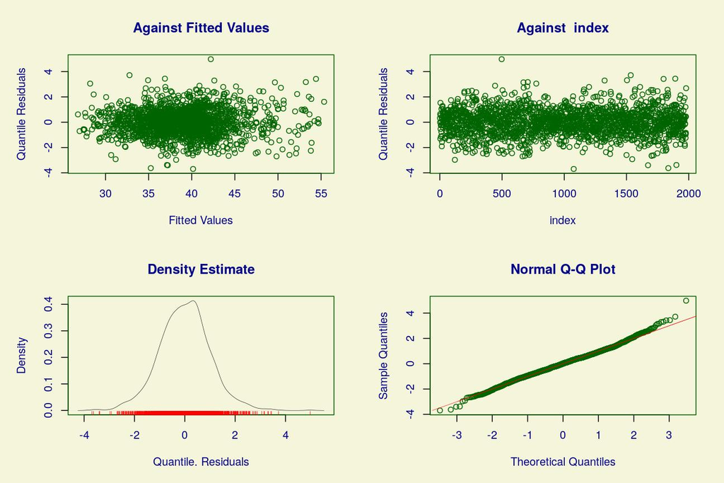

```
          Summary of the Quantile Residuals
                           mean   =  1.384527e-05
                       variance   =  1.000506
               coef. of skewness  =  0.09166289
               coef. of kurtosis  =  3.764844
Filliben correlation coefficient  =  0.9974381
```

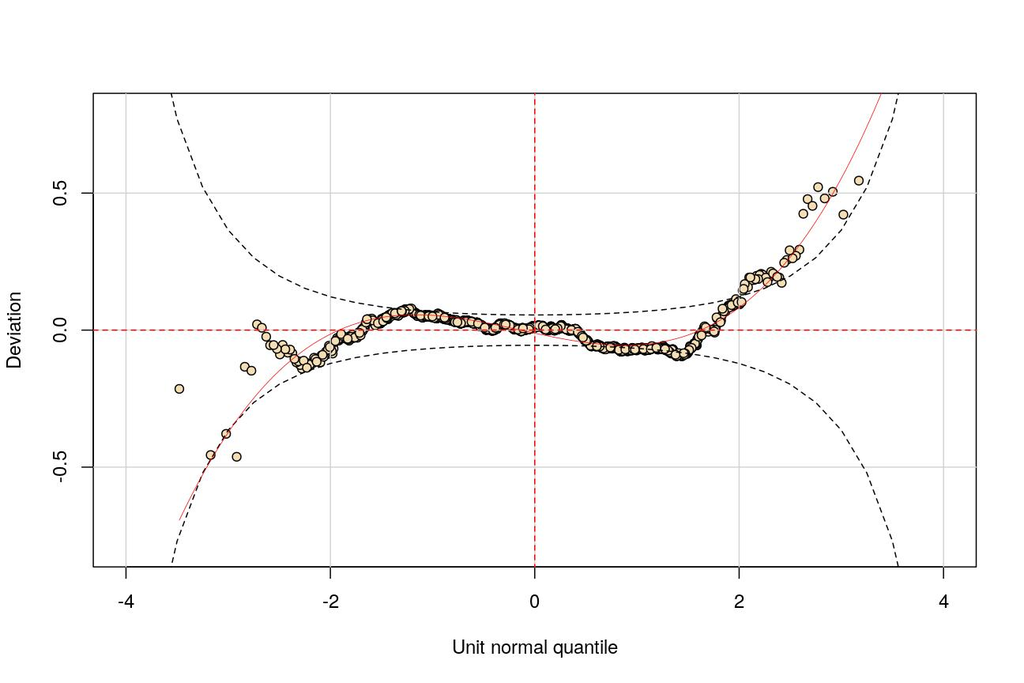

The model including *Age* * *Sex* is:

```
Family:  c("NO", "Normal")

Call:  gamlss(formula = IR ~ 1 + Sex * Age + random(Text) +      random(Language) + random(Family) + random(Speaker),      family = NO(mu.link = "identity"), data = info.rate.data.for.age,      control = gamlss.control(n.cyc = 800, trace = FALSE),
    i.control = glim.control(bf.cyc = 800))

Fitting method: RS()

------------------------------------------------------------------
Mu link function:  identity
Mu Coefficients:
             Estimate Std. Error t value Pr(>|t|)
(Intercept) 40.015135   0.137507 291.003  < 2e-16 ***
Sex1        -0.175295   0.137508  -1.275    0.203
Age         -0.035742   0.004288  -8.336  < 2e-16 ***
Sex1:Age    -0.023187   0.004288  -5.408 7.22e-08 ***
---
Signif. codes:  0 '***' 0.001 '**' 0.01 '*' 0.05 '.' 0.1 ' ' 1

------------------------------------------------------------------
Sigma link function:  log
Sigma Coefficients:
            Estimate Std. Error t value Pr(>|t|)
(Intercept)   0.6074     0.0159   38.21   <2e-16 ***
---
Signif. codes:  0 '***' 0.001 '**' 0.01 '*' 0.05 '.' 0.1 ' ' 1

------------------------------------------------------------------
NOTE: Additive smoothing terms exist in the formulas:
 i) Std. Error for smoothers are for the linear effect only.
ii) Std. Error for the linear terms maybe are not accurate.
------------------------------------------------------------------
No. of observations in the fit:  1979
Degrees of Freedom for the fit:  161.827
      Residual Deg. of Freedom:  1817.173
                      at cycle:  2

Global Deviance:     8020.303
            AIC:     8343.957
            SBC:     9248.626
```

The compared models are:

| Model | Deviance | AIC |
| --- | --- | --- |
| *Age* * *Sex* | 8020.3 | 8344 |
| *Age* + *Sex* | 8020.3 | 8342 |
| *Sex* | 8020.3 | 8340 |

So, even if *Age* has a significant (negative) effect and interaction with *Sex* (positive for males) – interestingly, in this case the main effect of *Sex* disappears –, adding it does not seem to be warranted…

###### Modelled *σ*

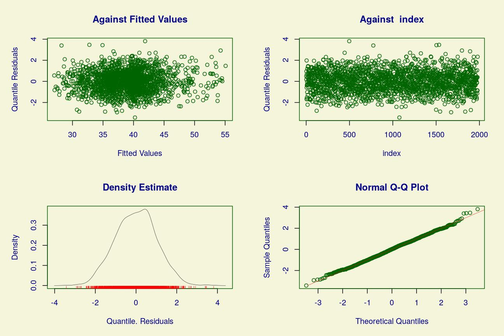

```
          Summary of the Quantile Residuals
                           mean   =  0.002387788
                       variance   =  1.00051
               coef. of skewness  =  0.02686615
               coef. of kurtosis  =  2.9163
Filliben correlation coefficient  =  0.9993496
```

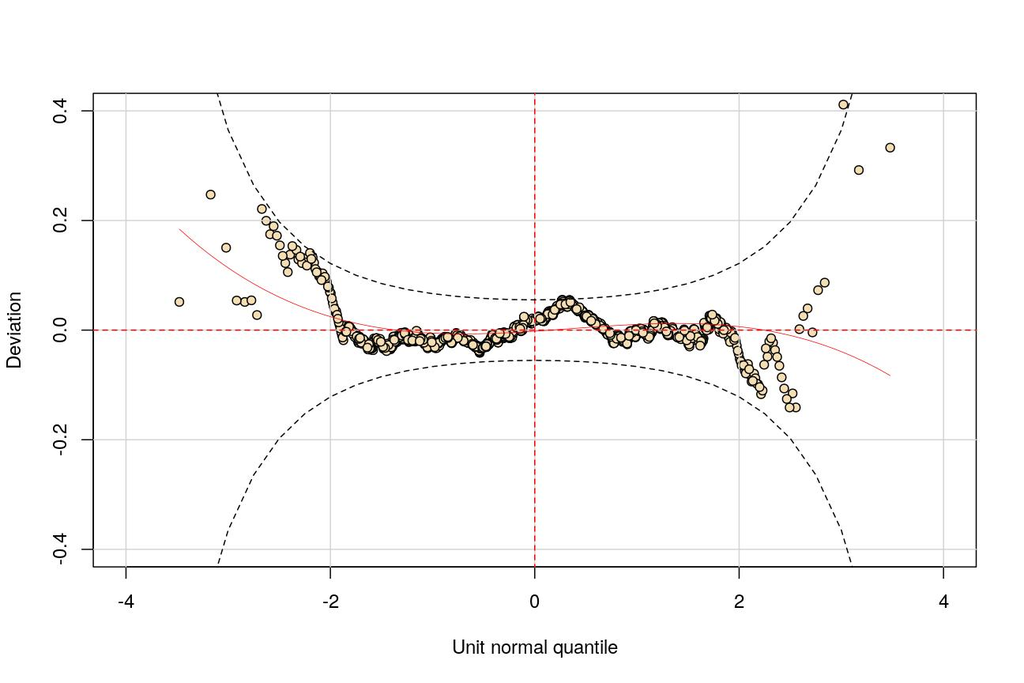

The model including *Age* * *Sex* is:

```
Family:  c("NO", "Normal")

Call:  gamlss(formula = IR ~ 1 + Sex * Age + random(Text) +      random(Language) + random(Family) + random(Speaker),      sigma.formula = ~1 + Sex * Age + random(Text) +          random(Language) + random(Family) + random(Speaker),
    family = NO(mu.link = "identity"), data = info.rate.data.for.age,      control = gamlss.control(n.cyc = 800, trace = FALSE),      i.control = glim.control(bf.cyc = 800))

Fitting method: RS()

------------------------------------------------------------------
Mu link function:  identity
Mu Coefficients:
             Estimate Std. Error t value Pr(>|t|)
(Intercept) 40.041563   0.118455 338.031  < 2e-16 ***
Sex1        -0.299328   0.118455  -2.527   0.0116 *
Age         -0.036894   0.003708  -9.950  < 2e-16 ***
Sex1:Age    -0.019096   0.003708  -5.150  2.9e-07 ***
---
Signif. codes:  0 '***' 0.001 '**' 0.01 '*' 0.05 '.' 0.1 ' ' 1

------------------------------------------------------------------
Sigma link function:  log
Sigma Coefficients:
             Estimate Std. Error t value Pr(>|t|)
(Intercept)  0.479445   0.053990   8.880   <2e-16 ***
Sex1         0.025025   0.053990   0.464    0.643
Age          0.001854   0.001685   1.100    0.271
Sex1:Age    -0.002747   0.001685  -1.630    0.103
---
Signif. codes:  0 '***' 0.001 '**' 0.01 '*' 0.05 '.' 0.1 ' ' 1

------------------------------------------------------------------
NOTE: Additive smoothing terms exist in the formulas:
 i) Std. Error for smoothers are for the linear effect only.
ii) Std. Error for the linear terms maybe are not accurate.
------------------------------------------------------------------
No. of observations in the fit:  1979
Degrees of Freedom for the fit:  244.3689
      Residual Deg. of Freedom:  1734.631
                      at cycle:  10

Global Deviance:     7726.653
            AIC:     8215.391
            SBC:     9581.498
```

The compared models are:

| Model | Deviance | AIC |
| --- | --- | --- |
| *Age* * *Sex* | 7726.7 | 8215.4 |
| *Age* + *Sex* | 7726.4 | 8212.2 |
| *Sex* | 7725.8 | 8208.8 |

The distribution of the residuals is less heteroscedastic than before and the fit to the data better.

##### Summary

Thus, while for *IR* the hint that *Age* has a negative main effect and interacts with *Sex* (with a positive effect for males, containing the whole effect of *Sex*) is much stronger, the various fit indices do not warrant its inclusion in the GAMLSS models.

### Modelling the relationship between SR and ID

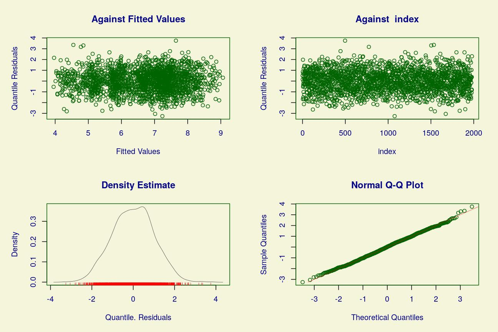

```
          Summary of the Quantile Residuals
                           mean   =  0.001744301
                       variance   =  1.000502
               coef. of skewness  =  0.008063776
               coef. of kurtosis  =  2.834364
Filliben correlation coefficient  =  0.9993747
```

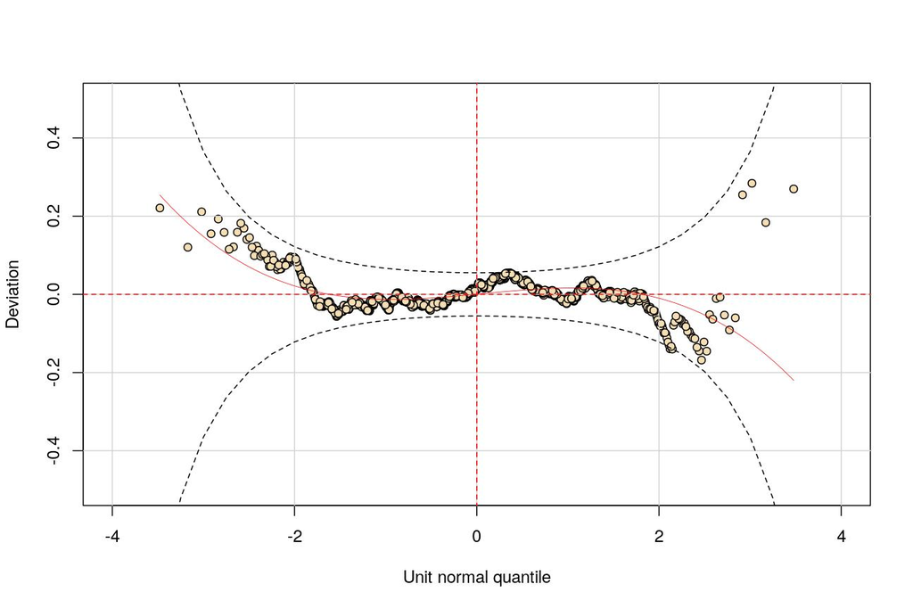

The model including *Age* * *Sex* is:

```
Family:  c("NO", "Normal")

Call:  gamlss(formula = SR ~ 1 + ID + Sex * Age + random(Text) +      random(Speaker) + random(Family), sigma.formula = ~1 +      ID + Sex * Age + random(Text) + random(Speaker) +      random(Family), family = NO(mu.link = "identity"),
    data = info.rate.data.for.age, control = gamlss.control(n.cyc = 800,          trace = FALSE), i.control = glim.control(bf.cyc = 800))

Fitting method: RS()

------------------------------------------------------------------
Mu link function:  identity
Mu Coefficients:
              Estimate Std. Error  t value Pr(>|t|)
(Intercept) 12.6793628  0.0517065  245.218  < 2e-16 ***
ID          -0.9813533  0.0071683 -136.903  < 2e-16 ***
Sex1         0.0102517  0.0204390    0.502    0.616
Age         -0.0059906  0.0006663   -8.991  < 2e-16 ***
Sex1:Age    -0.0050056  0.0006537   -7.658 3.12e-14 ***
---
Signif. codes:  0 '***' 0.001 '**' 0.01 '*' 0.05 '.' 0.1 ' ' 1

------------------------------------------------------------------
Sigma link function:  log
Sigma Coefficients:
             Estimate Std. Error t value Pr(>|t|)
(Intercept) -0.790248   0.133246  -5.931 3.63e-09 ***
ID          -0.086078   0.019128  -4.500 7.24e-06 ***
Sex1         0.046494   0.054368   0.855   0.3926
Age          0.001961   0.001718   1.141   0.2540
Sex1:Age    -0.003459   0.001698  -2.037   0.0418 *
---
Signif. codes:  0 '***' 0.001 '**' 0.01 '*' 0.05 '.' 0.1 ' ' 1

------------------------------------------------------------------
NOTE: Additive smoothing terms exist in the formulas:
 i) Std. Error for smoothers are for the linear effect only.
ii) Std. Error for the linear terms maybe are not accurate.
------------------------------------------------------------------
No. of observations in the fit:  1979
Degrees of Freedom for the fit:  236.269
      Residual Deg. of Freedom:  1742.731
                      at cycle:  8

Global Deviance:     705.2126
            AIC:     1177.751
            SBC:     2498.577
```

The compared models are:

| Model | Deviance | AIC |
| --- | --- | --- |
| *ID* * *Sex* * *Age* | 705.2 | 1188.4 |
| *ID* + *Sex* * *Age* | 705.2 | 1177.8 |
| *ID* * *Sex* + *Age* | 704.2 | 1178.2 |
| *ID* + *Sex* + *Age* | 704.5 | 1174.5 |
| *ID* * *Sex* | 704.4 | 1174.6 |
| *ID* + *Sex* | 704.6 | 1170.9 |

Clearly, adding *Age* is not warranted here (as is the interaction between *ID* and *Sex*)…

As above, we also looked at the simple lmer model:

The compared models are:

| Model | AIC |
| --- | --- |
| *ID* * *Sex* * *Age* | 1811.2 |
| *ID* + *Sex* * *Age* | 1790.7 |
| *ID* * *Sex* + *Age* | 1786.3 |
| *ID* + *Sex* + *Age* | 1781 |
| *ID* * *Sex* | 1777.8 |
| *ID* + *Sex* | 1772.5 |

The best model is still the one not including *Age*:

```
Linear mixed model fit by REML. t-tests use Satterthwaite's method ['lmerModLmerTest']
Formula: SR ~ 1 + ID + Sex + (1 | Text) + (1 | Speaker) + (1 | Family)
   Data: info.rate.data.for.age

REML criterion at convergence: 1758.5

Scaled residuals:
    Min      1Q  Median      3Q     Max
-3.8062 -0.6300  0.0174  0.5882  5.2084

Random effects:
 Groups   Name        Variance Std.Dev.
 Speaker  (Intercept) 0.35876  0.5990
 Text     (Intercept) 0.01494  0.1222
 Family   (Intercept) 0.26668  0.5164
 Residual             0.10575  0.3252
Number of obs: 1979, groups:  Speaker, 132; Text, 15; Family, 9

Fixed effects:
             Estimate Std. Error        df t value Pr(>|t|)
(Intercept)  10.80777    0.77185  27.12524  14.002 6.21e-14 ***
ID           -0.70707    0.12477  31.07295  -5.667 3.15e-06 ***
Sex1         -0.14683    0.05268 119.92464  -2.787  0.00618 **
---
Signif. codes:  0 '***' 0.001 '**' 0.01 '*' 0.05 '.' 0.1 ' ' 1

Correlation of Fixed Effects:
     (Intr) ID
ID   -0.971
Sex1 -0.001  0.003
```

### Conclusions about *Age*

Within the limits of our reduced dataset (containing only 132 speakers with *Age* info), we found the following:

When modelling *SR* and *IR* with *GAMLSS*, while there are hints that *Age* has, for both, overall:

- a **negative** main effect (i.e., *older* speakers of both sexes are *slower* and transmit *less information* per unit time across texts and languages), and
- an **interaction** with *Sex* (*positive* for *males*, i.e., males are *less negatively affected* by age that females across texts and languages),

It does *not* seem warranted to include it in these models.

When modelling the *relationship* between *SR* and *ID*, this *negative relationship*:

- seems **strengthened** with increasing *Age* (i.e., older speakers of both sexes show a stronger negative relationship between *SR* and *ID*), and
- there is an **interaction** with *Sex* (for females, this effect of *Age* is stronger than for males),

but, alas, the inclusion of *Age* is not warranted in the *GAMLSS model*, nor (really) in the simpler *LMER model*.

Thus, while *Age* seems to **negatively influence** (in a **sex-dependent manner**) both *SR* and *IR*, as well as **strengthen** the *negative relationship* between them, its effects are **far from clear** in the current dataset.

## Is there any relationship between *ID*, *Age* and *Sex*?

Here we test the hypothesis that *ID* is confounded by *Age* and *Sex* structures between languages:

```
Data: info.rate.data.for.age
Models:
model.ID.age: ID ~ Age + (1 | Family)
model.ID.age.sex: ID ~ 1 + Sex * Age + (1 | Family)
                 Df    AIC    BIC  logLik deviance  Chisq Chi Df Pr(>Chisq)
model.ID.age      4 1089.1 1111.5 -540.57   1081.1
model.ID.age.sex  6 1091.9 1125.5 -539.96   1079.9 1.2113      2     0.5457
```

```
Data: info.rate.data.for.age
Models:
model.ID: ID ~ (1 | Family)
model.ID.age.sex: ID ~ 1 + Sex * Age + (1 | Family)
                 Df    AIC    BIC  logLik deviance  Chisq Chi Df Pr(>Chisq)
model.ID          3 1088.2 1105.0 -541.09   1082.2
model.ID.age.sex  6 1091.9 1125.5 -539.96   1079.9 2.2555      3     0.5211
```

```
Linear mixed model fit by REML. t-tests use Satterthwaite's method ['lmerModLmerTest']
Formula: ID ~ 1 + Sex * Age + (1 | Family)
   Data: info.rate.data.for.age

REML criterion at convergence: 1113.3

Scaled residuals:
     Min       1Q   Median       3Q      Max
-1.17017 -0.67570 -0.01297  0.05397  2.96861

Random effects:
 Groups   Name        Variance Std.Dev.
 Family   (Intercept) 1.14186  1.0686
 Residual             0.09778  0.3127
Number of obs: 1979, groups:  Family, 9

Fixed effects:
              Estimate Std. Error         df t value Pr(>|t|)
(Intercept)  5.992e+00  3.571e-01  8.071e+00  16.778 1.46e-07 ***
Sex1        -2.587e-02  2.361e-02  1.967e+03  -1.096    0.273
Age          9.073e-04  8.119e-04  1.967e+03   1.118    0.264
Sex1:Age     7.923e-04  7.370e-04  1.967e+03   1.075    0.282
---
Signif. codes:  0 '***' 0.001 '**' 0.01 '*' 0.05 '.' 0.1 ' ' 1

Correlation of Fixed Effects:
         (Intr) Sex1   Age
Sex1      0.005
Age      -0.068 -0.087
Sex1:Age -0.005 -0.955  0.095
```

Thus, there does not seem to be any relationship between *ID*, *Age* and *Sex*.

## Relationship between *ID* and the *syntagmatic density of information ratio* (SDIR)

In our case, SDIR (versus *Vietnamese*) is reduced to the ratio between the number of syllables (*NS*) in *Vietnamese* and the *NS* in the language *L* for each *Text* separately; we denote this here also as *NSVR* (from “NS Vietnamese Ratio”).

### *SDIR* separately for each *Text* and *Language*

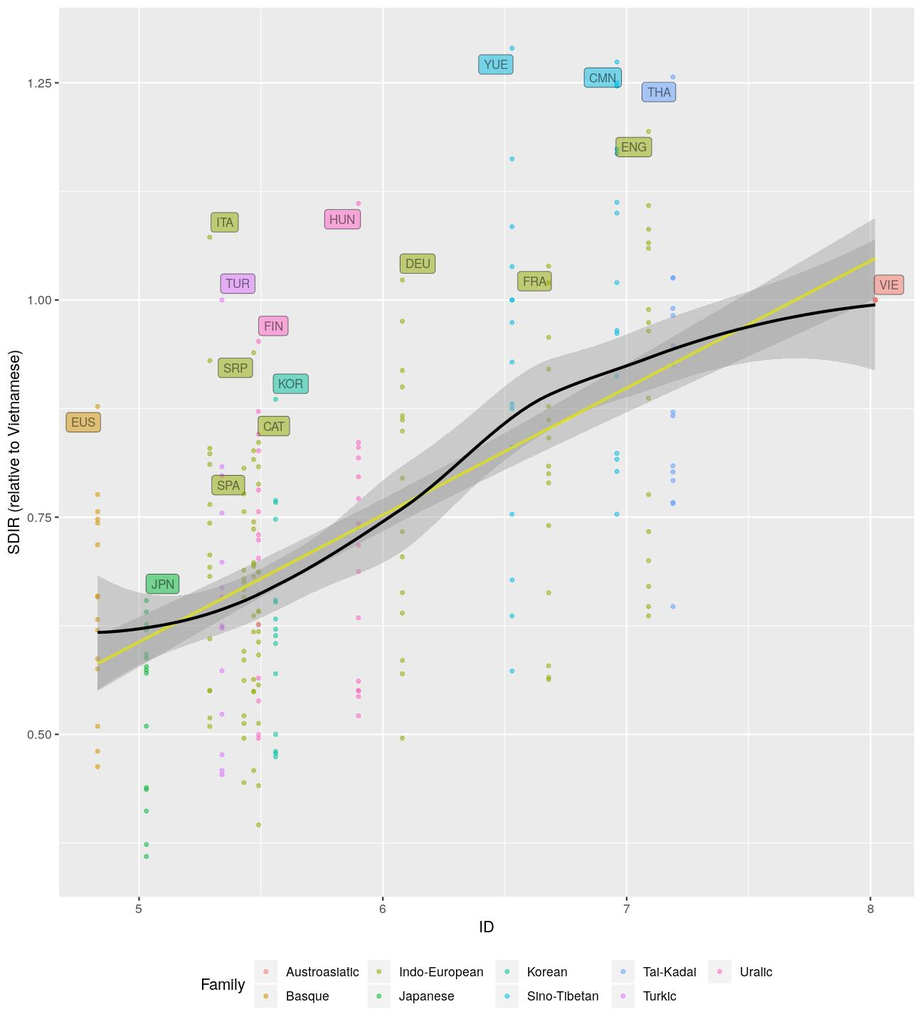

Syntagmatic density of information ratio *SDIR* (relative to Vietnamese) versus *ID* with LOESS smoother (black) and linear regression (yellow) and their 95%CIs.

The “flat” correlations (Pearson and Spearman) between *SDIR* and *ID* are:

```
    Pearson's product-moment correlation

data:  d$NSVR and d$ID
t = 13.46, df = 253, p-value < 2.2e-16
alternative hypothesis: true correlation is not equal to 0
95 percent confidence interval:
 0.5682215 0.7122938
sample estimates:
      cor
0.6459739
```

```
    Spearman's rank correlation rho

data:  d$NSVR and d$ID
S = 1108400, p-value < 2.2e-16
alternative hypothesis: true rho is not equal to 0
sample estimates:
      rho
0.5989002
```

The multi-level regression of *SDIR* on *ID* (with *Text* as random effect) and the *Text*’s ICC are:

```
Linear mixed model fit by REML. t-tests use Satterthwaite's method ['lmerModLmerTest']
Formula: NSVR ~ ID + (1 | Text)
   Data: d

REML criterion at convergence: -394.5

Scaled residuals:
    Min      1Q  Median      3Q     Max
-2.1594 -0.6786 -0.0734  0.5435  3.8668

Random effects:
 Groups   Name        Variance Std.Dev.
 Text     (Intercept) 0.013819 0.11755
 Residual             0.009879 0.09939
Number of obs: 255, groups:  Text, 15

Fixed effects:
              Estimate Std. Error         df t value Pr(>|t|)
(Intercept)  -0.124714   0.052989  98.407896  -2.354   0.0206 *
ID            0.146209   0.007138 239.000000  20.484   <2e-16 ***
---
Signif. codes:  0 '***' 0.001 '**' 0.01 '*' 0.05 '.' 0.1 ' ' 1

Correlation of Fixed Effects:
   (Intr)
ID -0.811
```

```
Intraclass Correlation Coefficient for Linear mixed model

Family : gaussian (identity)
Formula: NSVR ~ ID + (1 | Text)

  ICC (Text): 0.5831
```

### Average *SDIR* across *Text*s for each *Language*

If we consider just the **average *SDIR*** for each language:

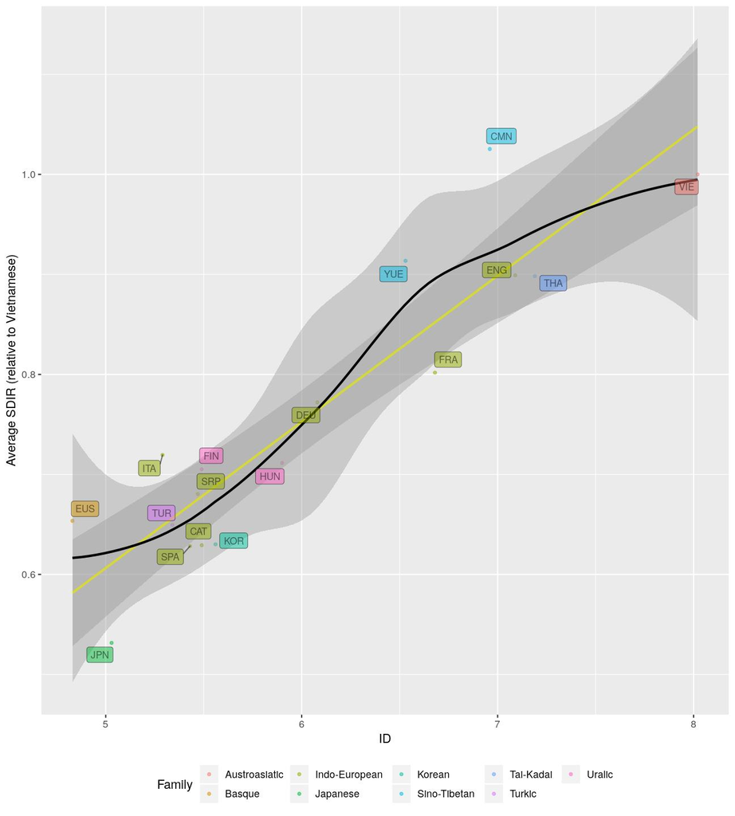

Average syntagmatic density of information ratio *SDIR* (relative to Vietnamese) versus *ID* with LOESS smoother (black) and linear regression (yellow) and their 95%CIs.

```
    Pearson's product-moment correlation

data:  d1$NSVR.mean and d1$ID
t = 8.6199, df = 15, p-value = 3.394e-07
alternative hypothesis: true correlation is not equal to 0
95 percent confidence interval:
 0.7683980 0.9682841
sample estimates:
      cor
0.9121585
```

```
    Spearman's rank correlation rho

data:  d1$NSVR.mean and d1$ID
S = 162.6, p-value = 0.0001126
alternative hypothesis: true rho is not equal to 0
sample estimates:
      rho
0.8007359
```

```
Call:
lm(formula = NSVR.mean ~ ID, data = d1)

Residuals:
     Min       1Q   Median       3Q      Max
-0.07917 -0.04788 -0.01277  0.02717  0.13245

Coefficients:
            Estimate Std. Error t value Pr(>|t|)
(Intercept) -0.12471    0.10321  -1.208    0.246
ID           0.14621    0.01696   8.620 3.39e-07 ***
---
Signif. codes:  0 '***' 0.001 '**' 0.01 '*' 0.05 '.' 0.1 ' ' 1

Residual standard error: 0.06098 on 15 degrees of freedom
Multiple R-squared:  0.832, Adjusted R-squared:  0.8208
F-statistic:  74.3 on 1 and 15 DF,  p-value: 3.394e-07
```

## Mixture of Gaussians

In what follows, mixing probabilities is done independently from factors such as Sex.

### SR

Between 1 and 5 Gaussian distributions:

*1 component*

```
Mixing Family:  "NO"

Fitting method: EM algorithm

Call:  gamlssMX(formula = SR ~ 1, family = NO, K = 1, data = d, plot = FALSE)

Mu Coefficients for model: 1
(Intercept)
      6.631
Sigma Coefficients for model: 1
(Intercept)
     0.1378

Estimated probabilities: 1

Degrees of Freedom for the fit: 2 Residual Deg. of Freedom   2286
Global Deviance:     7123.61
            AIC:     7127.61
            SBC:     7139.08
```

*2 components*

```
Mixing Family:  c("NO", "NO")

Fitting method: EM algorithm

Call:  gamlssMX(formula = SR ~ 1, family = NO, K = 2, data = d, plot = FALSE)

Mu Coefficients for model: 1
(Intercept)
       5.26
Sigma Coefficients for model: 1
(Intercept)
    -0.4778
Mu Coefficients for model: 2
(Intercept)
       7.15
Sigma Coefficients for model: 2
(Intercept)
    -0.1862

Estimated probabilities: 0.27457 0.72543

Degrees of Freedom for the fit: 5 Residual Deg. of Freedom   2283
Global Deviance:     7001.23
            AIC:     7011.23
            SBC:     7039.9
```

*3 components*

```
Mixing Family:  c("NO", "NO", "NO")

Fitting method: EM algorithm

Call:  gamlssMX(formula = SR ~ 1, family = NO, K = 3, data = d, plot = FALSE)

Mu Coefficients for model: 1
(Intercept)
      7.257
Sigma Coefficients for model: 1
(Intercept)
    -0.2162
Mu Coefficients for model: 2
(Intercept)
       6.44
Sigma Coefficients for model: 2
(Intercept)
    -0.1447
Mu Coefficients for model: 3
(Intercept)
      5.199
Sigma Coefficients for model: 3
(Intercept)
    -0.5124

Estimated probabilities: 0.590421 0.1746332 0.2349458

Degrees of Freedom for the fit: 8 Residual Deg. of Freedom   2280
Global Deviance:     7001.95
            AIC:     7017.95
            SBC:     7063.84
```

*4 components*

```
Mixing Family:  c("NO", "NO", "NO", "NO")

Fitting method: EM algorithm

Call:  gamlssMX(formula = SR ~ 1, family = NO, K = 4, data = d, plot = FALSE)

Mu Coefficients for model: 1
(Intercept)
      7.012
Sigma Coefficients for model: 1
(Intercept)
   -0.03502
Mu Coefficients for model: 2
(Intercept)
      5.323
Sigma Coefficients for model: 2
(Intercept)
    -0.4349
Mu Coefficients for model: 3
(Intercept)
      7.257
Sigma Coefficients for model: 3
(Intercept)
   -0.09049
Mu Coefficients for model: 4
(Intercept)
        7.2
Sigma Coefficients for model: 4
(Intercept)
    -0.6349

Estimated probabilities: 0.231015 0.2886475 0.2650284 0.2153091

Degrees of Freedom for the fit: 11 Residual Deg. of Freedom   2277
Global Deviance:     6996.59
            AIC:     7018.59
            SBC:     7081.68
```

*5 components*

```
Mixing Family:  c("NO", "NO", "NO", "NO", "NO")

Fitting method: EM algorithm

Call:  gamlssMX(formula = SR ~ 1, family = NO, K = 5, data = d, plot = FALSE)

Mu Coefficients for model: 1
(Intercept)
      6.772
Sigma Coefficients for model: 1
(Intercept)
    -0.1062
Mu Coefficients for model: 2
(Intercept)
      7.611
Sigma Coefficients for model: 2
(Intercept)
    -0.2516
Mu Coefficients for model: 3
(Intercept)
      7.207
Sigma Coefficients for model: 3
(Intercept)
     -1.041
Mu Coefficients for model: 4
(Intercept)
      5.339
Sigma Coefficients for model: 4
(Intercept)
    -0.4062
Mu Coefficients for model: 5
(Intercept)
      6.852
Sigma Coefficients for model: 5
(Intercept)
    -0.1055

Estimated probabilities: 0.1783584 0.2294359 0.1266083 0.2811023 0.1844951

Degrees of Freedom for the fit: 14 Residual Deg. of Freedom   2274
Global Deviance:     6988.48
            AIC:     7016.48
            SBC:     7096.78
```

*Comparing AIC*

```
            df      AIC
mix.SR.NO.2  5 7011.225
mix.SR.NO.5 14 7016.484
mix.SR.NO.3  8 7017.954
mix.SR.NO.4 11 7018.591
mix.SR.NO.1  2 7127.609
```

*Showing the distributions*

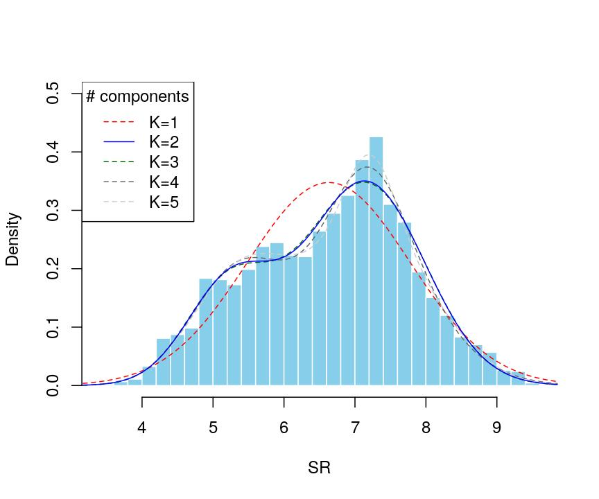

Mixture of Gaussians for SR.

### IR

Between 1 and 5 Gaussian distributions:

*1 component*

```
Mixing Family:  "NO"

Fitting method: EM algorithm

Call:  gamlssMX(formula = IR ~ 1, family = NO, K = 1, data = d, plot = FALSE)

Mu Coefficients for model: 1
(Intercept)
      39.15
Sigma Coefficients for model: 1
(Intercept)
      1.629

Estimated probabilities: 1

Degrees of Freedom for the fit: 2 Residual Deg. of Freedom   2286
Global Deviance:     13945.2
            AIC:     13949.2
            SBC:     13960.7
```

*2 components*

```
Mixing Family:  c("NO", "NO")

Fitting method: EM algorithm

Call:  gamlssMX(formula = IR ~ 1, family = NO, K = 2, data = d, plot = FALSE)

Mu Coefficients for model: 1
(Intercept)
      41.16
Sigma Coefficients for model: 1
(Intercept)
      1.861
Mu Coefficients for model: 2
(Intercept)
      38.38
Sigma Coefficients for model: 2
(Intercept)
      1.442

Estimated probabilities: 0.2770978 0.7229022

Degrees of Freedom for the fit: 5 Residual Deg. of Freedom   2283
Global Deviance:     13895
            AIC:     13905
            SBC:     13933.7
```

*3 components*

```
Mixing Family:  c("NO", "NO", "NO")

Fitting method: EM algorithm

Call:  gamlssMX(formula = IR ~ 1, family = NO, K = 3, data = d, plot = FALSE)

Mu Coefficients for model: 1
(Intercept)
      40.01
Sigma Coefficients for model: 1
(Intercept)
     0.9221
Mu Coefficients for model: 2
(Intercept)
      42.61
Sigma Coefficients for model: 2
(Intercept)
      1.713
Mu Coefficients for model: 3
(Intercept)
      35.75
Sigma Coefficients for model: 3
(Intercept)
      1.374

Estimated probabilities: 0.2997471 0.3102765 0.3899765

Degrees of Freedom for the fit: 8 Residual Deg. of Freedom   2280
Global Deviance:     13875.7
            AIC:     13891.7
            SBC:     13937.6
```

*4 components*

```
Mixing Family:  c("NO", "NO", "NO", "NO")

Fitting method: EM algorithm

Call:  gamlssMX(formula = IR ~ 1, family = NO, K = 4, data = d, plot = FALSE)

Mu Coefficients for model: 1
(Intercept)
      39.59
Sigma Coefficients for model: 1
(Intercept)
     0.7231
Mu Coefficients for model: 2
(Intercept)
      42.84
Sigma Coefficients for model: 2
(Intercept)
      1.772
Mu Coefficients for model: 3
(Intercept)
      40.16
Sigma Coefficients for model: 3
(Intercept)
      1.364
Mu Coefficients for model: 4
(Intercept)
      34.43
Sigma Coefficients for model: 4
(Intercept)
      1.254

Estimated probabilities: 0.2027138 0.2280114 0.3066644 0.2626103

Degrees of Freedom for the fit: 11 Residual Deg. of Freedom   2277
Global Deviance:     13870.5
            AIC:     13892.5
            SBC:     13955.6
```

*5 components*

```
Mixing Family:  c("NO", "NO", "NO", "NO", "NO")

Fitting method: EM algorithm

Call:  gamlssMX(formula = IR ~ 1, family = NO, K = 5, data = d, plot = FALSE)

Mu Coefficients for model: 1
(Intercept)
      34.41
Sigma Coefficients for model: 1
(Intercept)
      1.261
Mu Coefficients for model: 2
(Intercept)
      43.85
Sigma Coefficients for model: 2
(Intercept)
       1.77
Mu Coefficients for model: 3
(Intercept)
      39.55
Sigma Coefficients for model: 3
(Intercept)
     0.5825
Mu Coefficients for model: 4
(Intercept)
      40.27
Sigma Coefficients for model: 4
(Intercept)
       1.35
Mu Coefficients for model: 5
(Intercept)
      40.07
Sigma Coefficients for model: 5
(Intercept)
      1.376

Estimated probabilities: 0.2666359 0.1665143 0.1540443 0.2038578 0.2089478

Degrees of Freedom for the fit: 14 Residual Deg. of Freedom   2274
Global Deviance:     13868.7
            AIC:     13896.7
            SBC:     13977
```

*Comparing AIC*

```
            df      AIC
mix.IR.NO.3  8 13891.72
mix.IR.NO.4 11 13892.47
mix.IR.NO.5 14 13896.74
mix.IR.NO.2  5 13905.05
mix.IR.NO.1  2 13949.21
```

*Showing the distributions*

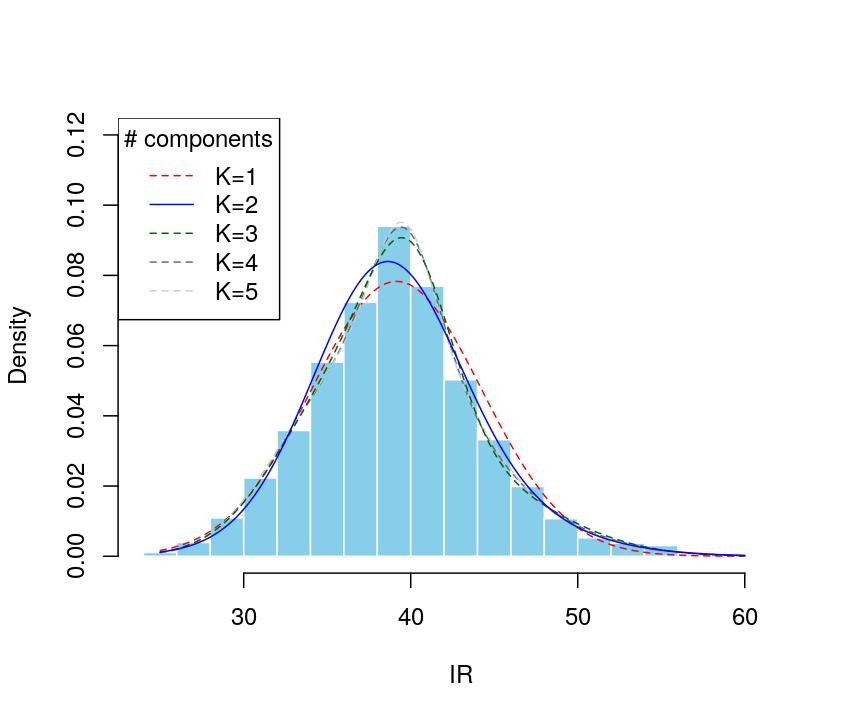

Mixture of Gaussians for IR.

## Tests of unimodality

We used three ways to estimate how unimodal a distribution is, as they tend to disagree and the problem of unimodality testing is far from settled (see Freeman & Dale, 2013):

- the **Silverman test** tests the null hypothesis that an underlying density has at most *k* modes (H0: number of modes <= *k*). The result is the *p*-value (bootstrapped) of rejecting a unimodal distribution. It is described in Silverman (1981) and Hall & York (2001); our implementation is based on the code available at https://www.mathematik.uni-marburg.de/~stochastik/R_packages/;
- the **dip test** which computes Hartigans’ dip statistic *$D_n$*, and its *p*-value for the test for unimodality, by interpolating tabulated quantiles of *sqrt(n) • $D_n$*. For *$X_i$* ∼ *F*, i.i.d., the null hypothesis is that *F* is a unimodal distribution. The result is the *D* metric and the *p*-value (interpolated) of rejecting a unimodal distribution. See Hartigan (1985) and Hartigan & Hartigan (1985); it is implemented in package `diptest`;
- the **bimodality coefficient** (BC) which is based on an empirical relationship between bimodality and the third and fourth statistical moments of a distribution (skewness and kurtosis). It is proportional to the division of squared skewness with uncorrected kurtosis, *BC* ≈ (*s*<sup>2</sup> + 1)/*k*, with the underlying logic that a bimodal distribution will have very low kurtosis, an asymmetric character, or both; all of these conditions increase *BC*. The values range from 0 and 1, with those exceeding .555 (the value representing a uniform distribution) suggesting bi-modality. The result is the *DC* estimate (which must exceed 0.555 to reject a unimodal distribution). We implemented it following Freeman & Dale (2013) as *BC* = (*s*<sup>2</sup> + 1)/(*k* + 3 • ((n-1)<sup>2</sup> / ((n-2) • (n-3)))).

For each such test, we performed four randomisation procedures to obtain an estimate of the “specialness” of the observed unimodality estimate; for each new permuted dataset, we recomputed everything before estimating the unimodality of the permuted distribution:

- Permutation model 1 (**PM1**): randomly permute the SR values freely among speakers, texts and languages;
- Permutation model 2 (**PM2**): randomly permute the ID values among languages;
- Permutation model 3 (**PM3**): randomly permute the Speaker average SR values among speakers (irrespective of languages);
- Permutation model 4 (**PM4**): randomly permute the Language average SR values among languages.

### Visual comparison

The observed estimate (vertical blue solid line), the permuted distribution (gray histogram), and the “unimodality region” (shaded green rectangle) are shown below (for PM3, we also show the original estimate using the Speaker average SR as a vertical solid red line).

#### PM1

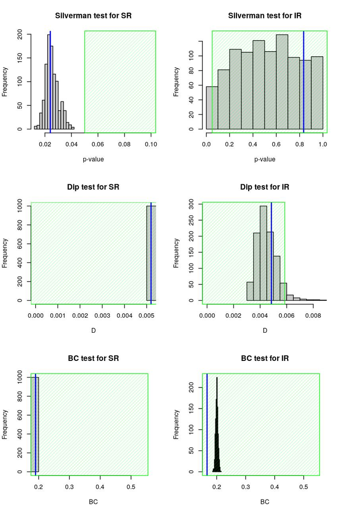

**Permutation of the SRs of the texts (PM1)**.

#### PM2

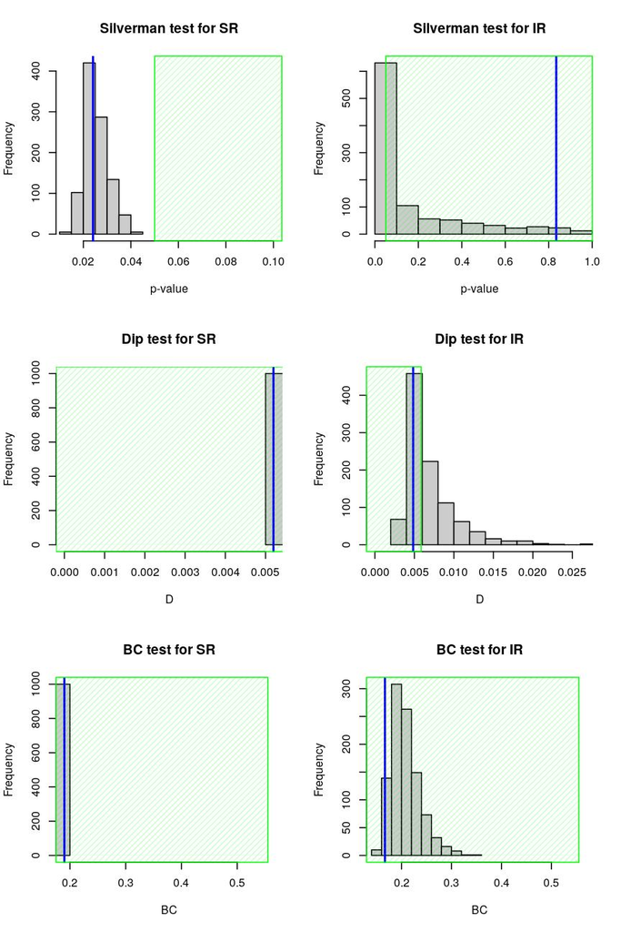

**Permutation of the IDs of the languages (PM2)**.

#### PM3

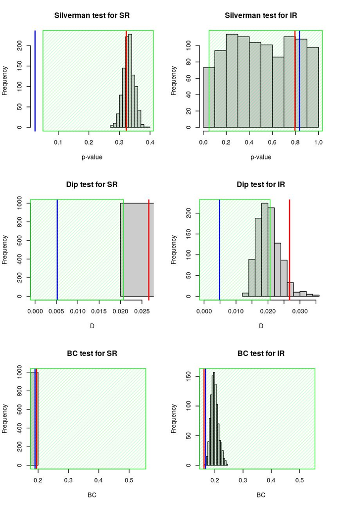

**Permutation of the speakers’ average SRs (PM3)**.

#### PM4

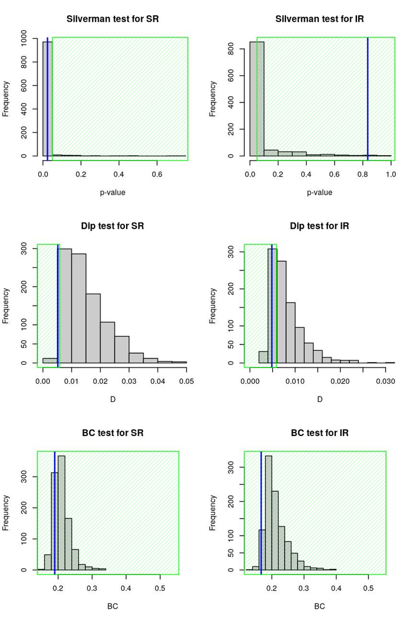

**Permutation of the average SRs of the languages with speaker adjustement (PM4)**.

#### Summary of unimodality tests

Summary of unimodality permutation tests.

| Scenario | Measure | Test | Observed estimate (*p*-value) | % more unimodal permutations |
| --- | --- | --- | --- | --- |
| PM1 | SR | Silverman | - (0.024) | 55.5% |
| PM1 | SR | Dip | 0.005 (0.984) * | 100% |
| PM1 | SR | BC | 0.19 () * | 100% |
| PM1 | IR | Silverman | - (0.835) * | 15.3% |
| PM1 | IR | Dip | 0.005 (0.992) * | 71% |
| PM1 | IR | BC | 0.167 () * | 100% |
| PM2 | SR | Silverman | - (0.024) | 56.4% |
| PM2 | SR | Dip | 0.005 (0.984) * | 100% |
| PM2 | SR | BC | 0.19 () * | 100% |
| PM2 | IR | Silverman | - (0.835) * | 2.7% |
| PM2 | IR | Dip | 0.005 (0.992) * | 25.9% |
| PM2 | IR | BC | 0.167 () * | 97.3% |
| PM3 | SR | Silverman | - (0.024) | 100% |
| PM3 | SR | Dip | 0.005 (0.984) * | 0% |
| PM3 | SR | BC | 0.19 () * | 100% |
| PM3 | IR | Silverman | - (0.835) * | 16.8% |
| PM3 | IR | Dip | 0.005 (0.992) * | 17.5% |
| PM3 | IR | BC | 0.167 () * | 100% |
| PM4 | SR | Silverman | - (0.024) | 4.1% |
| PM4 | SR | Dip | 0.005 (0.984) * | 1.5% |
| PM4 | SR | BC | 0.19 () * | 82.8% |
| PM4 | IR | Silverman | - (0.835) * | 0.7% |
| PM4 | IR | Dip | 0.005 (0.992) * | 13% |
| PM4 | IR | BC | 0.167 () * | 96.8% |

## Pair-wise distances between languages

We compute various distances between languages (as implemented by the `distance()` function in package `philentropy`) in what concerns the distribution of NS, SR and ID.

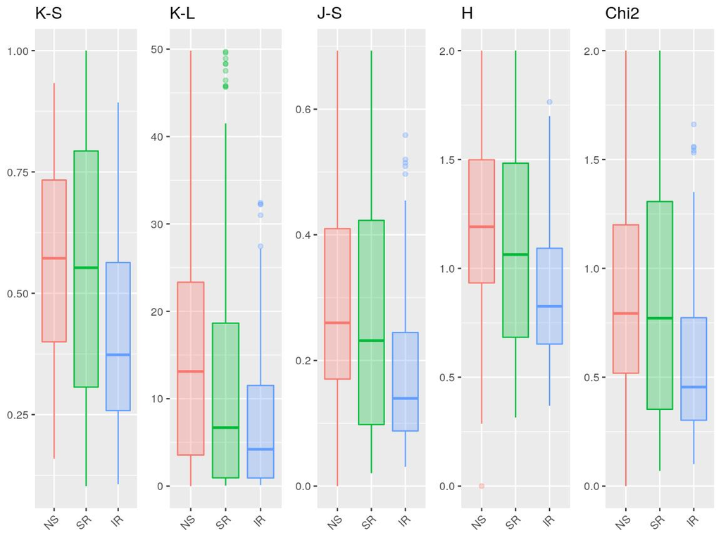

Comparing the distribution of pairwise distances between languages.

Paired permutation t-tests comparing measures with 1,000 permutations.

| m1 | m2 | d | mean1 | median1 | sd1 | mean2 | median2 | sd2 | p |
| --- | --- | --- | --- | --- | --- | --- | --- | --- | --- |
| IR | NS | Hellinger | 0.88 | 0.83 | 0.32 | 1.20 | 1.19 | 0.39 | 0.00 |
| IR | NS | Jensen-Shannon | 0.17 | 0.14 | 0.12 | 0.29 | 0.26 | 0.16 | 0.00 |
| IR | NS | Kolmogorov–Smirnov | 0.42 | 0.37 | 0.20 | 0.57 | 0.57 | 0.23 | 0.00 |
| IR | NS | Kullback-Leibler | 7.13 | 4.22 | 7.81 | 15.42 | 13.12 | 13.31 | 0.00 |
| IR | NS | Squared-Chi | 0.56 | 0.45 | 0.36 | 0.88 | 0.79 | 0.47 | 0.00 |
| IR | SR | Hellinger | 0.88 | 0.83 | 0.32 | 1.10 | 1.06 | 0.48 | 0.00 |
| IR | SR | Jensen-Shannon | 0.17 | 0.14 | 0.12 | 0.27 | 0.23 | 0.20 | 0.00 |
| IR | SR | Kolmogorov–Smirnov | 0.42 | 0.37 | 0.20 | 0.56 | 0.55 | 0.27 | 0.00 |
| IR | SR | Kullback-Leibler | 7.13 | 4.22 | 7.81 | 12.80 | 6.69 | 14.88 | 0.00 |
| IR | SR | Squared-Chi | 0.56 | 0.45 | 0.36 | 0.86 | 0.77 | 0.57 | 0.00 |
| NS | SR | Hellinger | 1.20 | 1.19 | 0.39 | 1.10 | 1.06 | 0.48 | 0.01 |
| NS | SR | Jensen-Shannon | 0.29 | 0.26 | 0.16 | 0.27 | 0.23 | 0.20 | 0.30 |
| NS | SR | Kolmogorov–Smirnov | 0.57 | 0.57 | 0.23 | 0.56 | 0.55 | 0.27 | 0.81 |
| NS | SR | Kullback-Leibler | 15.42 | 13.12 | 13.31 | 12.80 | 6.69 | 14.88 | 0.05 |
| NS | SR | Squared-Chi | 0.88 | 0.79 | 0.47 | 0.86 | 0.77 | 0.57 | 0.62 |

## References

Campione, E., & Véronis, J. (1998). A multilingual prosodic database, *Proc. of the 5th International Conference on Spoken Language Pro cessing (ICSLP’98), Sydney, Australia*, 3163-3166.

Freeman, J. B., & Dale, R. (2013). Assessing bimodality to detect the presence of a dual cognitive process. *Behavior research methods*, **45**(1), 83-97.

Hall, P., & York, M. (2001). On the calibration of Silverman’s test for multimodality. *Statistica Sinica*, **11**, 515-536.

Hartigan, J. A., & Hartigan, P. M. (1985) The Dip Test of Unimodality. *Annals of Statistics* **13**, 70–84.

Hartigan, P. M. (1985) Computation of the Dip Statistic to Test for Unimodality. *Applied Statistics (JRSS C)* **34**, 320–325.

Le, V. B., Tran, D. D., Castelli, E., Besacier, L., & Serignat, J. F. (2004). Spoken and Written Language Resources for Vietnamese. In *LREC. 4*, pp. 599-602.

Lyding, V., Stemle, E., Borghetti, C., Brunello, M., Castagnoli, S., Dell’Orletta, F., Dittmann, H., Lenci, A., & Pirrelli, V. (2014). The PAISÀ Corpus of Italian Web Texts. In *Proceedings of the 9th Web as Corpus Workshop (WaC-9). Association for Computational Linguistics, Gothenburg, Sweden*, 36-43.

New B., Pallier C., Ferrand L., & Matos R. (2001). Une base de données lexicales du français contemporain sur internet: LEXIQUE 3.80, *L’Année Psychologique*, **101**, 447-462. http://www.lexique.org.

Oh, Y. M. (2015). *Linguistic complexity and information: quantitative approaches*. PhD Thesis, Université de Lyon, France. Retrieved from http://www.afcp-parole.org/doc/theses/these_YMO15.pdf

Perea, M., Urkia, M., Davis, C. J., Agirre, A., Laseka, E., & Carreiras, M. (2006). E-Hitz: A word frequency list and a program for deriving psycholinguistic statistics in an agglutinative language (Basque). *Behavior Research Methods*, **38(4)**, 610-615.

Sharoff, S. (2006). Creating general-purpose corpora using automated search engine queries. In Baroni, M. and Bernardini, S. (Eds.) *WaCky! Working papers on the web as corpus, Gedit, Bologna*, http://corpus.leeds.ac.uk/queryzh.html.

Silverman, B.W. (1981). Using Kernel Density Estimates to investigate Multimodality. *Journal of the Royal Statistical Society, Series B*, **43**, 97-99.

Váradi, T. (2002). The Hungarian National Corpus. In *LREC*.

Zséder, A., Recski, G., Varga, D., & Kornai, A. (2012). Rapid creation of large-scale corpora and frequency dictionaries. In *Proceedings to LREC 2012*.

## Appendix I: `R` session info

This document was compiled on:

**R version 3.4.4 (2018-03-15)**

**Platform:** x86_64-pc-linux-gnu (64-bit)

**locale:** *LC_CTYPE=en_US.UTF-8*, *LC_NUMERIC=C*, *LC_TIME=en_US.UTF-8*, *LC_COLLATE=en_US.UTF-8*, *LC_MONETARY=en_US.UTF-8*, *LC_MESSAGES=en_US.UTF-8*, *LC_PAPER=en_US.UTF-8*, *LC_NAME=C*, *LC_ADDRESS=C*, *LC_TELEPHONE=C*, *LC_MEASUREMENT=en_US.UTF-8* and *LC_IDENTIFICATION=C*

**attached base packages:** *grid*, *parallel*, *splines*, *stats*, *graphics*, *grDevices*, *datasets*, *utils*, *methods* and *base*

**other attached packages:** *broman(v.0.69-5)*, *philentropy(v.0.3.0)*, *pander(v.0.6.3)*, *moments(v.0.14)*, *sjPlot(v.2.6.3)*, *sjstats(v.0.17.4)*, *gamlss.mx(v.4.3-5)*, *nnet(v.7.3-12)*, *gamlss(v.5.1-3)*, *nlme(v.3.1-139)*, *gamlss.dist(v.5.1-3)*, *MASS(v.7.3-51.4)*, *gamlss.data(v.5.1-3)*, *lmerTest(v.3.1-0)*, *lme4(v.1.1-21)*, *Matrix(v.1.2-17)*, *plyr(v.1.8.4)*, *reshape2(v.1.4.3)*, *ggrepel(v.0.8.0)*, *ggplot2(v.3.1.1)* and *RhpcBLASctl(v.0.18-205)*

**loaded via a namespace (and not attached):** *tidyr(v.0.8.3)*, *modelr(v.0.1.4)*, *assertthat(v.0.2.1)*, *highr(v.0.8)*, *yaml(v.2.2.0)*, *bayestestR(v.0.1.0)*, *numDeriv(v.2016.8-1)*, *pillar(v.1.3.1)*, *backports(v.1.1.4)*, *lattice(v.0.20-38)*, *glue(v.1.3.1)*, *digest(v.0.6.18)*, *glmmTMB(v.0.2.3)*, *minqa(v.1.2.4)*, *colorspace(v.1.4-1)*, *sandwich(v.2.5-1)*, *htmltools(v.0.3.6)*, *psych(v.1.8.12)*, *pkgconfig(v.2.0.2)*, *broom(v.0.5.2)*, *haven(v.2.1.0)*, *purrr(v.0.3.2)*, *xtable(v.1.8-4)*, *mvtnorm(v.1.0-8)*, *scales(v.1.0.0)*, *emmeans(v.1.3.4)*, *tibble(v.2.1.1)*, *generics(v.0.0.2)*, *sjlabelled(v.1.0.17)*, *TH.data(v.1.0-10)*, *withr(v.2.1.2)*, *TMB(v.1.7.15)*, *lazyeval(v.0.2.2)*, *mnormt(v.1.5-5)*, *survival(v.2.44-1.1)*, *magrittr(v.1.5)*, *crayon(v.1.3.4)*, *estimability(v.1.3)*, *evaluate(v.0.13)*, *foreign(v.0.8-71)*, *forcats(v.0.4.0)*, *tools(v.3.4.4)*, *hms(v.0.4.2)*, *multcomp(v.1.4-8)*, *stringr(v.1.4.0)*, *munsell(v.0.5.0)*, *ggeffects(v.0.9.0)*, *compiler(v.3.4.4)*, *rlang(v.0.3.4)*, *nloptr(v.1.2.1)*, *labeling(v.0.3)*, *rmarkdown(v.1.12)*, *boot(v.1.3-22)*, *gtable(v.0.3.0)*, *codetools(v.0.2-16)*, *sjmisc(v.2.7.9)*, *R6(v.2.4.0)*, *zoo(v.1.8-5)*, *knitr(v.1.22)*, *dplyr(v.0.8.0.1)*, *performance(v.0.1.0)*, *insight(v.0.2.0)*, *stringi(v.1.4.3)*, *Rcpp(v.1.0.1)*, *tidyselect(v.0.2.5)*, *xfun(v.0.6)* and *coda(v.0.19-2)*

## Appendix II: Speech Rate: Canonical vs. automatic detection

Here we compare the Speech Rate (*SR*) used in the paper and defined as the *canonical articulatory rate* (= the number of syllables corresponding to the canonical text pronunciation per second of speech) with an estimate of the *realized speech rate*, based on the *automatic detection* of syllable nuclei implemented by the popular algorithm described in De Jong, Nivja H., and Ton Wempe. “Praat script to detect syllable nuclei and measure speech rate automatically.” Behavior research methods 41.2 (2009): 385-390. We used their algorithm with standard parameters (except for pauses which were retrieved from our manual annotation to match the main analysis) on the actual oral productions of our speakers, and the results are available in the TAB-separated CSV file `AutomaticSylDetect.csv` with the following structure:

- **soundname**: combination of Language, Text and Speaker info
- **nsyll**: number of syllables
- **npause**: number of pauses
- **dur**: total duration
- **phonationtime**: actual duration

### NS (# of syllables):

Pearson’s correlation and paired t-test:

```
    Pearson's product-moment correlation

data:  syll.data$NS and syll.data$NS.auto
t = 57.58, df = 2286, p-value < 2.2e-16
alternative hypothesis: true correlation is not equal to 0
95 percent confidence interval:
 0.7520760 0.7855572
sample estimates:
      cor
0.7693444
```

```
    Spearman's rank correlation rho

data:  syll.data$NS and syll.data$NS.auto
S = 455450000, p-value < 2.2e-16
alternative hypothesis: true rho is not equal to 0
sample estimates:
      rho
0.7718458
```

```
    Paired t-test

data:  syll.data$NS and syll.data$NS.auto
t = 59.48, df = 2287, p-value < 2.2e-16
alternative hypothesis: true difference in means is not equal to 0
95 percent confidence interval:
 19.08661 20.38804
sample estimates:
mean of the differences
               19.73733
```

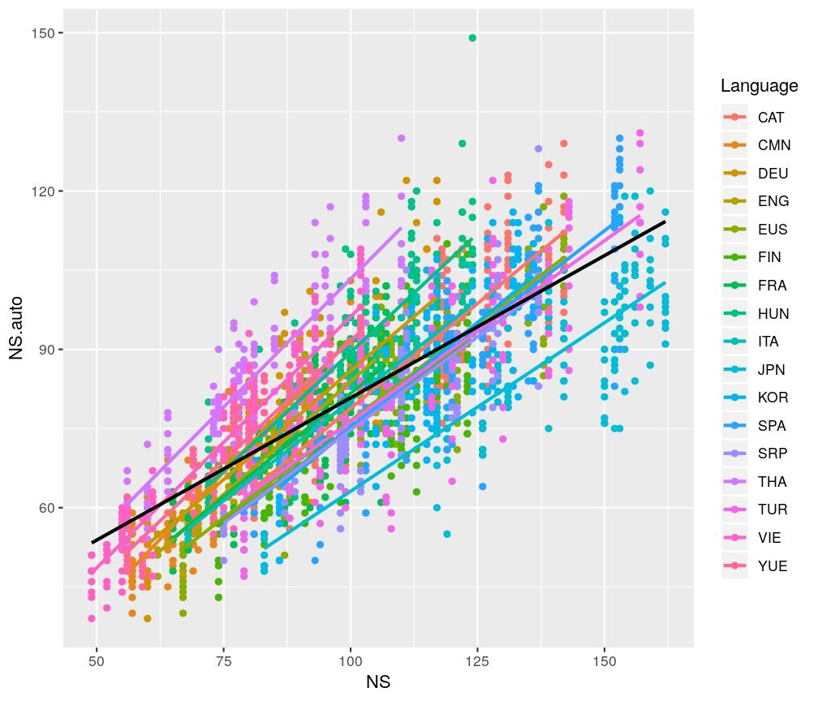

NS: canonical (x axis) vs automatic (y axis) overall (black) and separately by language (colored).

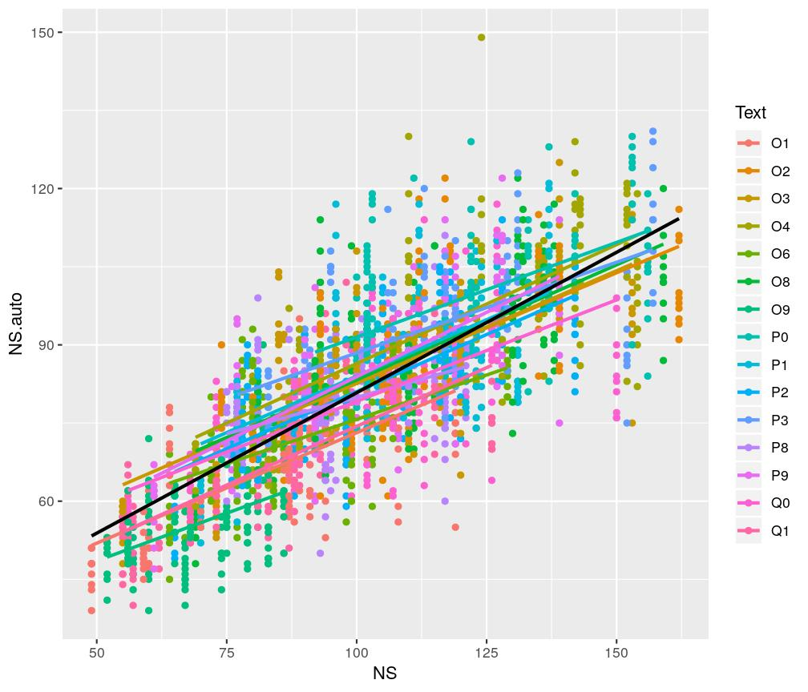

NS: canonical (x axis) vs automatic (y axis) overall (black) and separately by text (colored).

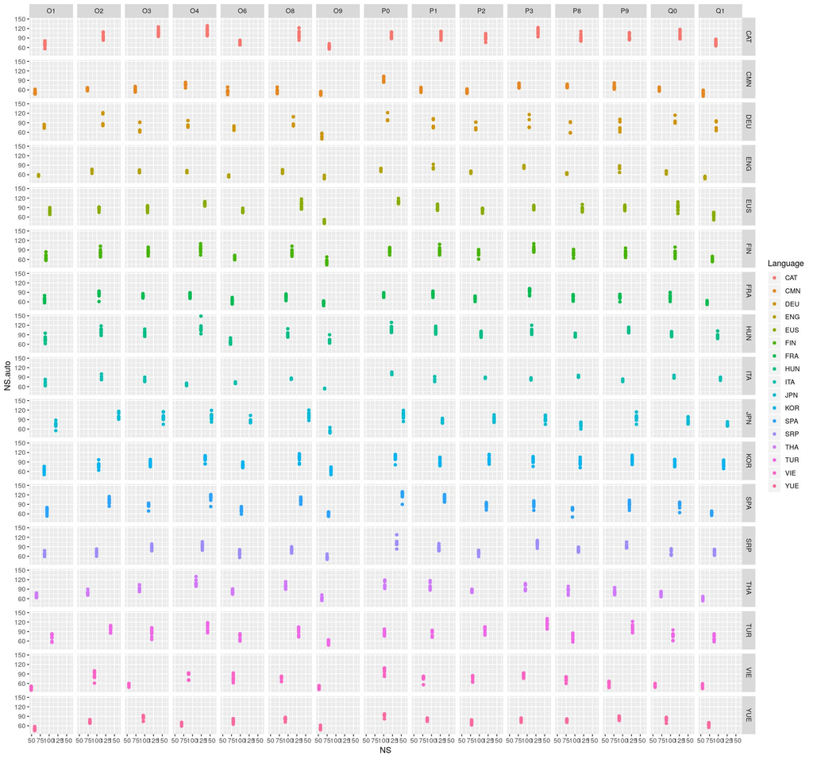

NS: canonical (x axis) vs automatic (y axis) separately by text and language.

### SR (speech rate):

Pearson’s correlation and paired t-test:

```
    Pearson's product-moment correlation

data:  syll.data$SR and syll.data$SR.auto
t = 27.135, df = 2286, p-value < 2.2e-16
alternative hypothesis: true correlation is not equal to 0
95 percent confidence interval:
 0.4619458 0.5239624
sample estimates:
      cor
0.4935813
```

```
    Spearman's rank correlation rho

data:  syll.data$SR and syll.data$SR.auto
S = 1059600000, p-value < 2.2e-16
alternative hypothesis: true rho is not equal to 0
sample estimates:
      rho
0.4691952
```

```
    Paired t-test

data:  syll.data$SR and syll.data$SR.auto
t = 64.226, df = 2287, p-value < 2.2e-16
alternative hypothesis: true difference in means is not equal to 0
95 percent confidence interval:
 1.302039 1.384054
sample estimates:
mean of the differences
               1.343047
```

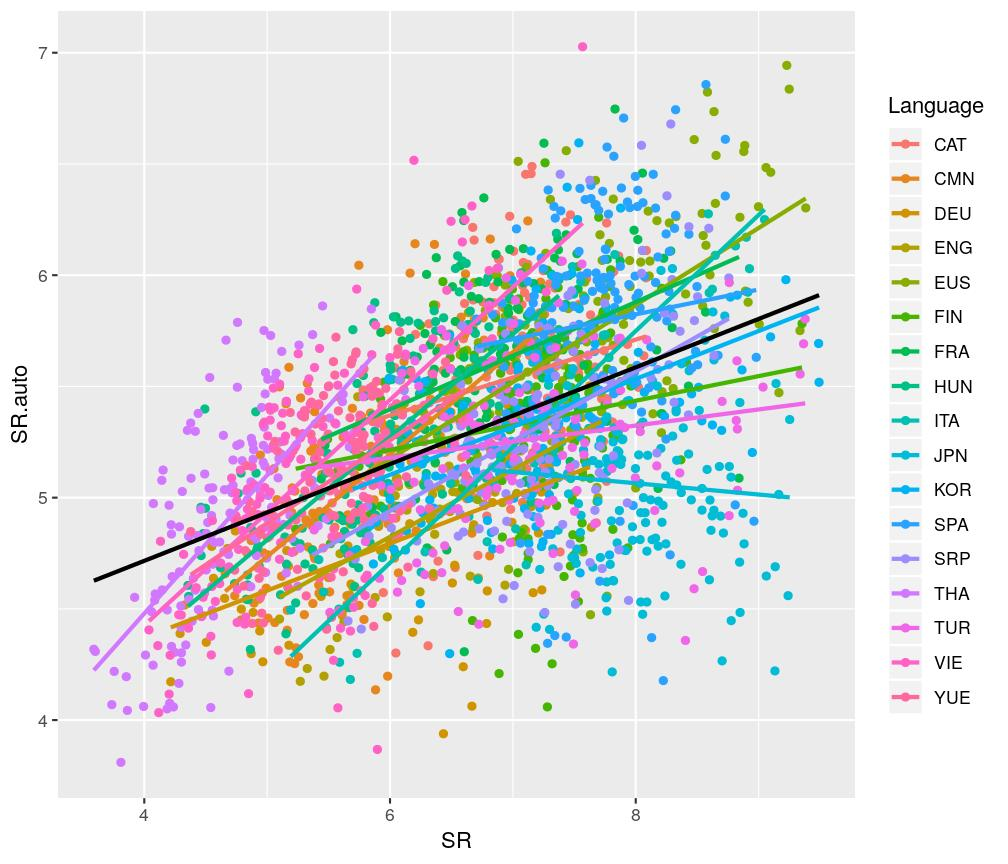

SR: canonical (x axis) vs automatic (y axis) overall (black) and separately by language (colored).

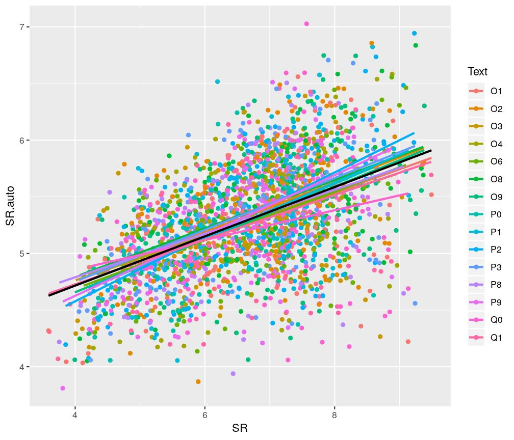

SR: canonical (x axis) vs automatic (y axis) overall (black) and separately by text (colored).

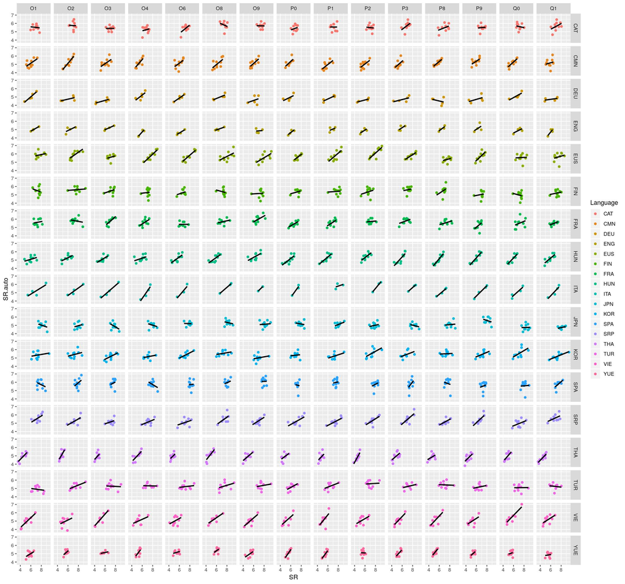

SR: canonical (x axis) vs automatic (y axis) separately by text and language.

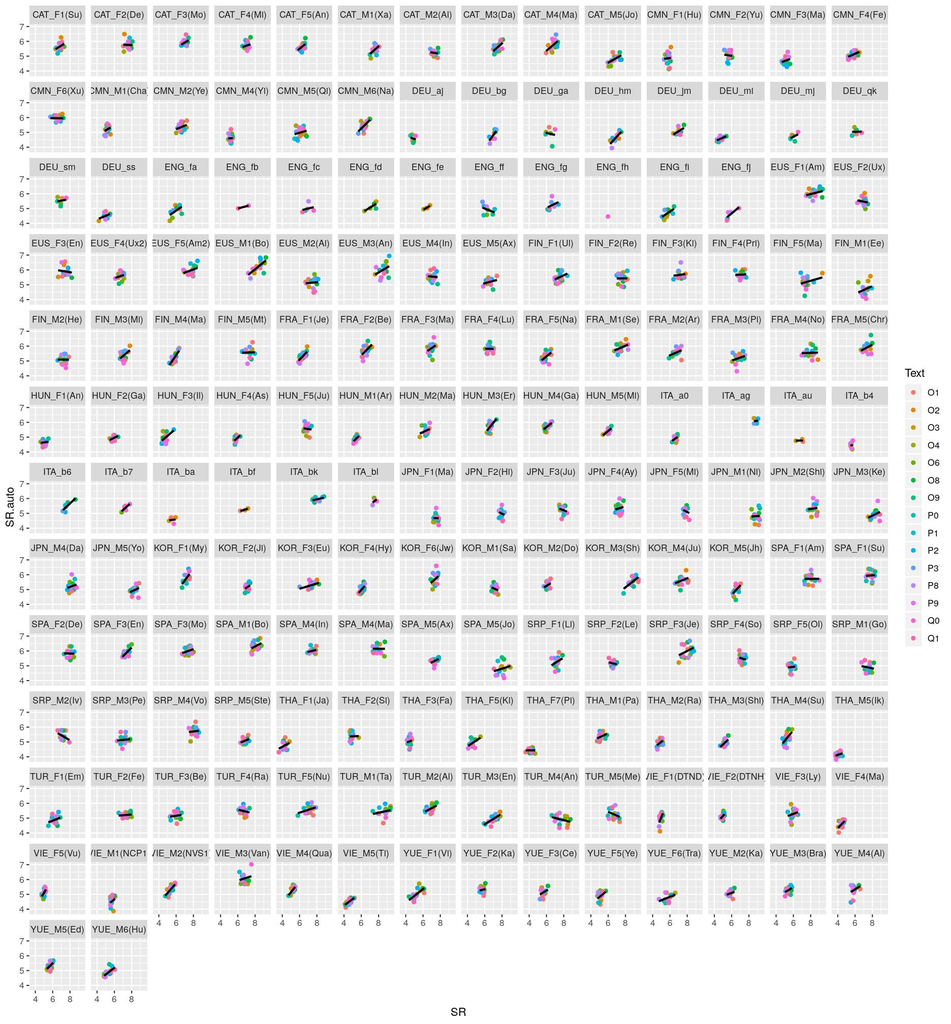

SR: canonical (x axis) vs automatic (y axis) separately by speaker.

#### Canonical and automatic SR by language

Plot, linear (mixed-effects) regression, correlation and paired t-tests:

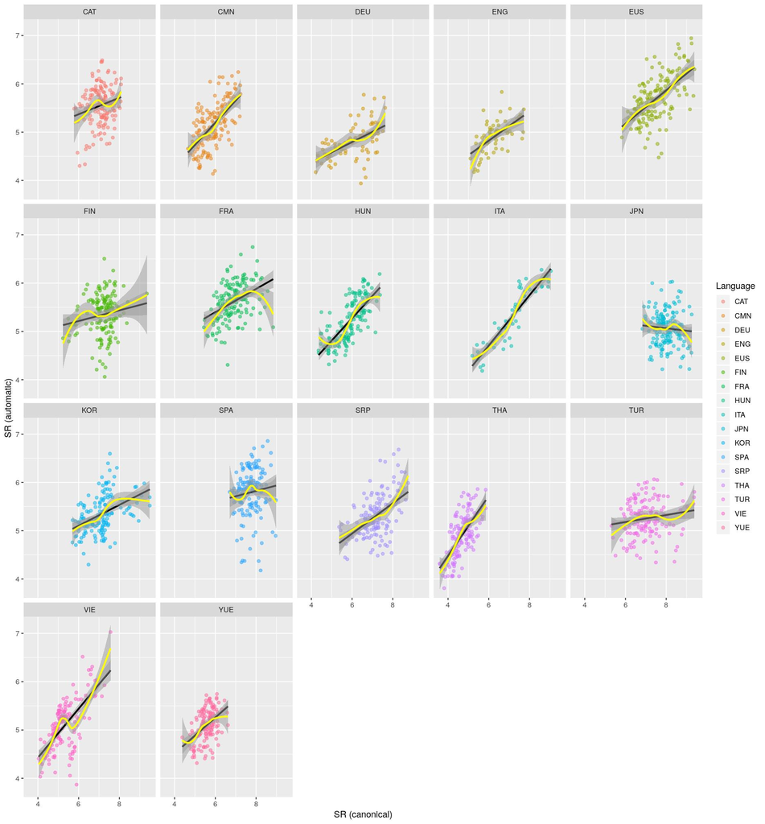

SR: canonical (x axis) vs automatic (y axis) separately by language with regression line (black) and LOESS smoothing (yellow) and their 95%CIs.

**Across languages:**

```
Linear mixed model fit by REML. t-tests use Satterthwaite's method ['lmerModLmerTest']
Formula: SR.auto ~ SR + (1 | Family/Language) + (1 | Text) + (1 | Speaker)
   Data: syll.data

REML criterion at convergence: 1044.7

Scaled residuals:
    Min      1Q  Median      3Q     Max
-3.4153 -0.6165 -0.0139  0.6006  3.4939

Random effects:
 Groups          Name        Variance  Std.Dev.
 Speaker         (Intercept) 8.152e-02 2.855e-01
 Language:Family (Intercept) 4.036e-02 2.009e-01
 Text            (Intercept) 1.510e-03 3.886e-02
 Family          (Intercept) 1.542e-10 1.242e-05
 Residual                    7.367e-02 2.714e-01
Number of obs: 2288, groups:  Speaker, 170; Language:Family, 17; Text, 15; Family, 9

Fixed effects:
             Estimate Std. Error        df t value Pr(>|t|)
(Intercept) 3.657e+00  1.167e-01 2.102e+02   31.34   <2e-16 ***
SR          2.425e-01  1.556e-02 1.269e+03   15.58   <2e-16 ***
---
Signif. codes:  0 '***' 0.001 '**' 0.01 '*' 0.05 '.' 0.1 ' ' 1

Correlation of Fixed Effects:
   (Intr)
SR -0.883
convergence code: 0
boundary (singular) fit: see ?isSingular
```

```
Intraclass Correlation Coefficient for Linear mixed model

Family : gaussian (identity)
Formula: SR.auto ~ SR + (1 | Family/Language) + (1 | Text) + (1 | Speaker)

          ICC (Speaker): 0.4137
  ICC (Language:Family): 0.2048
             ICC (Text): 0.0077
           ICC (Family): 0.0000
```

**For each language separately:**

```
For *CAT*

Linear mixed model fit by REML. t-tests use Satterthwaite's method ['lmerModLmerTest']
Formula: SR.auto ~ SR + (1 | Text) + (1 | Speaker)
   Data: d

REML criterion at convergence: 31.8

Scaled residuals:
    Min      1Q  Median      3Q     Max
-2.0701 -0.6506 -0.0219  0.4436  3.1370

Random effects:
 Groups   Name        Variance Std.Dev.
 Text     (Intercept) 0.01294  0.1137
 Speaker  (Intercept) 0.11321  0.3365
 Residual             0.04915  0.2217
Number of obs: 150, groups:  Text, 15; Speaker, 10

Fixed effects:
            Estimate Std. Error       df t value Pr(>|t|)
(Intercept)   3.6072     0.4748 141.6269   7.598 3.74e-12 ***
SR            0.2751     0.0653 146.8828   4.213 4.38e-05 ***
---
Signif. codes:  0 '***' 0.001 '**' 0.01 '*' 0.05 '.' 0.1 ' ' 1

Correlation of Fixed Effects:
   (Intr)
SR -0.972

Intraclass Correlation Coefficient for Linear mixed model

Family : gaussian (identity)
Formula: SR.auto ~ SR + (1 | Text) + (1 | Speaker)

     ICC (Text): 0.0738
  ICC (Speaker): 0.6458


For *CMN*
```

[output cut: 612 more lines]

```
SR            0.4951     0.0622 147.6043   7.960 4.20e-13 ***
---
Signif. codes:  0 '***' 0.001 '**' 0.01 '*' 0.05 '.' 0.1 ' ' 1

Correlation of Fixed Effects:
   (Intr)
SR -0.981

Intraclass Correlation Coefficient for Linear mixed model

Family : gaussian (identity)
Formula: SR.auto ~ SR + (1 | Text) + (1 | Speaker)

     ICC (Text): 0.1839
  ICC (Speaker): 0.3546
```

Correlations (Pearson’s and Spearman’s), paired t-test, and (mixed-effects, with Text, Speaker and, for the first row only, Language, as random effects) linear regression intercept and slope between automatic and canonical SR across all languages (top row) and for each language spearately).

| Language | Pearson’s r | Spearman’s rho | Paired t-test | Intercept | Slope |
| --- | --- | --- | --- | --- | --- |
| all | r=0.49 (p=8.445e-141) | rho=0.47 (p=1.327e-125) | t(2287.0)=64.23 (p=0) | 3.66 (p=3.57e-81) | 0.24 (p=3.1e-50) |
| CAT | r=0.21 (p=0.009915) | rho=0.12 (p=0.1506) | t(149.0)=32.05 (p=9.71e-69) | 3.61 (p=3.74e-12) | 0.28 (p=4.38e-05) |
| CMN | r=0.61 (p=1.557e-16) | rho=0.58 (p=4.102e-15) | t(149.0)=17.88 (p=6.52e-39) | 3.31 (p=2.43e-10) | 0.31 (p=9.36e-05) |
| DEU | r=0.54 (p=6.05e-07) | rho=0.58 (p=3.847e-08) | t(74.0)=13.19 (p=4.09e-21) | 3.28 (p=1.05e-07) | 0.25 (p=0.000854) |
| ENG | r=0.60 (p=5.205e-07) | rho=0.60 (p=3.885e-07) | t(59.0)=20.08 (p=4.63e-28) | 2.84 (p=3.35e-05) | 0.33 (p=0.000252) |
| EUS | r=0.58 (p=5.564e-15) | rho=0.57 (p=1.539e-14) | t(149.0)=34.65 (p=3.43e-73) | 3.45 (p=4.54e-10) | 0.30 (p=7.31e-06) |
| FIN | r=0.16 (p=0.0509) | rho=0.12 (p=0.1481) | t(149.0)=32.16 (p=6.37e-69) | 4.13 (p=3.3e-11) | 0.17 (p=0.0279) |
| FRA | r=0.41 (p=2.346e-07) | rho=0.43 (p=3.183e-08) | t(149.0)=24.94 (p=4.79e-55) | 3.85 (p=5.7e-13) | 0.26 (p=0.000144) |
| HUN | r=0.73 (p=5.921e-26) | rho=0.76 (p=8.644e-30) | t(149.0)=16.80 (p=3.31e-36) | 2.81 (p=3.28e-09) | 0.41 (p=6.36e-08) |
| ITA | r=0.92 (p=2.878e-22) | rho=0.93 (p=0) | t(53.0)=24.40 (p=1.7e-30) | 2.26 (p=2.34e-05) | 0.43 (p=4.2e-07) |
| JPN | r=-0.07 (p=0.3829) | rho=-0.05 (p=0.5309) | t(149.0)=55.12 (p=5.28e-101) | 3.59 (p=3.6e-07) | 0.18 (p=0.0259) |
| KOR | r=0.43 (p=3.817e-08) | rho=0.48 (p=3.552e-10) | t(149.0)=30.44 (p=7.77e-66) | 2.92 (p=5.25e-09) | 0.34 (p=2.53e-07) |
| SPA | r=0.10 (p=0.2028) | rho=0.16 (p=0.05311) | t(149.0)=36.69 (p=1.66e-76) | 4.28 (p=1.88e-12) | 0.20 (p=0.00498) |
| SRP | r=0.51 (p=2.448e-11) | rho=0.47 (p=1.443e-09) | t(149.0)=36.54 (p=2.91e-76) | 3.70 (p=7.63e-11) | 0.22 (p=0.00128) |
| THA | r=0.67 (p=1.331e-20) | rho=0.64 (p=0) | t(149.0)=-6.94 (p=1.1e-10) | 3.17 (p=5.61e-14) | 0.37 (p=2.07e-06) |
| TUR | r=0.16 (p=0.0467) | rho=0.16 (p=0.05116) | t(148.0)=25.12 (p=3.01e-55) | 4.23 (p=1.69e-15) | 0.14 (p=0.0134) |
| VIE | r=0.67 (p=3.979e-21) | rho=0.61 (p=8.736e-17) | t(149.0)=5.10 (p=1.03e-06) | 2.40 (p=4.19e-07) | 0.51 (p=7.33e-09) |
| YUE | r=0.45 (p=5.825e-09) | rho=0.43 (p=4.186e-08) | t(149.0)=15.22 (p=3.85e-32) | 2.34 (p=6.41e-10) | 0.50 (p=4.2e-13) |

## Appendix III: Figures for the main paper

Here we generate the figures used in the main paper (saved to the `./figures` folder as 600 DPI TIFF files `Figure-*.tiff`).